# Đồ án kết thúc học phần Mô hình hóa Thống kê

Lê Hoàng Như

03/08/2026

# Phân tích và dự báo mức thu nhập hàng tháng

## Mục tiêu và cách thực hiện

Bộ dữ liệu được dùng cho hai mục tiêu khác nhau và hai mục tiêu này được tách riêng:

1. **Phân tích các yếu tố liên quan đến thu nhập:** sử dụng ANOVA và hồi quy tuyến tính. Các hệ số được diễn giải như **mối liên hệ**.
2. **Đánh giá khả năng dự báo của mô hình:** ước lượng `MonthlyIncome` cho nhân viên trước quyết định lương. Mọi bước chọn biến và xây dựng mô hình được thực hiện trên tập Train; tập Test chỉ dùng để đánh giá cuối cùng.

Dữ liệu IBM HR là dữ liệu **mô phỏng**. Báo cáo gọi `MonthlyIncome` là “thu nhập hàng tháng theo đơn vị của bộ dữ liệu”, không mặc định đơn vị đó là USD khi chưa có tài liệu nguồn xác nhận.

# 1. Kiểm tra và tiền xử lý dữ liệu

## 1.1. Kiểm tra dữ liệu khuyết và dữ liệu trùng lặp

```r
df_raw <- read.csv(
  "data/WA_Fn-UseC_-HR-Employee-Attrition.csv",
  stringsAsFactors = FALSE
)

required_columns <- c(
  "MonthlyIncome", "EmployeeNumber", "JobLevel", "JobRole",
  "Department", "Gender", "TotalWorkingYears", "YearsAtCompany"
)
stopifnot(all(required_columns %in% names(df_raw)))

constant_cols <- names(df_raw)[
  vapply(df_raw, function(x) length(unique(x)) == 1, FUN.VALUE = logical(1))
]

content_for_duplicate_check <- df_raw %>%
  select(-any_of(c("EmployeeNumber", constant_cols)))

invalid_year_relations <- sum(
  df_raw$YearsAtCompany > df_raw$TotalWorkingYears |
    df_raw$YearsInCurrentRole > df_raw$YearsAtCompany |
    df_raw$YearsWithCurrManager > df_raw$YearsAtCompany |
    df_raw$YearsSinceLastPromotion > df_raw$YearsAtCompany
)

data_audit <- tibble(
  `Kiểm tra` = c(
    "Số quan sát", "Số biến", "Tổng giá trị khuyết",
    "EmployeeNumber bị trùng", "Dòng trùng sau khi bỏ ID/hằng số",
    "Biến chỉ có một giá trị", "Quan hệ thâm niên bất hợp lý"
  ),
  `Kết quả` = c(
    nrow(df_raw), ncol(df_raw), sum(is.na(df_raw)),
    sum(duplicated(df_raw$EmployeeNumber)),
    sum(duplicated(content_for_duplicate_check)),
    length(constant_cols), invalid_year_relations
  )
)

knitr::kable(data_audit, caption = "Kết quả kiểm tra dữ liệu ban đầu")
```

Kết quả kiểm tra dữ liệu ban đầu

| Kiểm tra | Kết quả |
| --- | --- |
| Số quan sát | 1470 |
| Số biến | 35 |
| Tổng giá trị khuyết | 0 |
| EmployeeNumber bị trùng | 0 |
| Dòng trùng sau khi bỏ ID/hằng số | 0 |
| Biến chỉ có một giá trị | 3 |
| Quan hệ thâm niên bất hợp lý | 0 |

```r
cat("Các biến hằng số:", paste(constant_cols, collapse = ", "))
```

```
## Các biến hằng số: EmployeeCount, Over18, StandardHours
```

Không có dòng trùng, dữ liệu khuyết hoặc quan hệ thâm niên bất hợp lý. Vì vậy, báo cáo không cần điền giá trị khuyết hoặc xóa quan sát. Ba biến chỉ có một giá trị không cung cấp thông tin cho mô hình.

## 1.2. Loại biến không phù hợp và chuyển đổi kiểu dữ liệu

Mô hình được giả định sử dụng **trước khi quyết định lương**. Vì vậy, ngoài mã nhân viên và các biến chỉ có một giá trị, báo cáo loại những biến phản ánh kết quả xảy ra sau đó hoặc thông tin lương, đãi ngộ đã biết sẵn. Cách làm này tránh đưa thông tin không phù hợp vào mô hình dự báo.

```r
policy_excluded <- c(
  "EmployeeNumber", "EmployeeCount", "Over18", "StandardHours",
  "Attrition", "DailyRate", "HourlyRate", "MonthlyRate",
  "PercentSalaryHike", "StockOptionLevel"
)

feature_policy <- tibble(
  `Biến bị loại` = policy_excluded,
  `Lý do` = c(
    "Mã định danh", "Biến hằng", "Biến hằng", "Biến hằng",
    "Kết quả xảy ra sau/không phù hợp thời điểm dự báo",
    rep("Thông tin lương hoặc đãi ngộ đồng thời", 4),
    "Quyết định đãi ngộ đồng thời"
  )
)
knitr::kable(feature_policy, caption = "Các biến không được dùng để dự báo thu nhập")
```

Các biến không được dùng để dự báo thu nhập

| Biến bị loại | Lý do |
| --- | --- |
| EmployeeNumber | Mã định danh |
| EmployeeCount | Biến hằng |
| Over18 | Biến hằng |
| StandardHours | Biến hằng |
| Attrition | Kết quả xảy ra sau/không phù hợp thời điểm dự báo |
| DailyRate | Thông tin lương hoặc đãi ngộ đồng thời |
| HourlyRate | Thông tin lương hoặc đãi ngộ đồng thời |
| MonthlyRate | Thông tin lương hoặc đãi ngộ đồng thời |
| PercentSalaryHike | Thông tin lương hoặc đãi ngộ đồng thời |
| StockOptionLevel | Quyết định đãi ngộ đồng thời |

```r
df_model <- df_raw %>%
  select(-all_of(policy_excluded)) %>%
  mutate(
    JobLevel = factor(JobLevel),
    PerformanceRating = factor(PerformanceRating),
    Education = factor(Education),
    EnvironmentSatisfaction = factor(EnvironmentSatisfaction),
    JobInvolvement = factor(JobInvolvement),
    JobSatisfaction = factor(JobSatisfaction),
    RelationshipSatisfaction = factor(RelationshipSatisfaction),
    WorkLifeBalance = factor(WorkLifeBalance)
  ) %>%
  mutate(across(where(is.character), factor)) %>%
  mutate(
    JobLevel = stats::relevel(JobLevel, ref = "1"),
    JobRole = stats::relevel(JobRole, ref = "Sales Executive"),
    Education = stats::relevel(Education, ref = "3"),
    PerformanceRating = stats::relevel(PerformanceRating, ref = "3"),
    Gender = stats::relevel(Gender, ref = "Female")
  )

stopifnot(sum(is.na(df_model)) == 0)

type_summary <- tibble(
  `Kiểu dữ liệu` = names(table(vapply(df_model, class, character(1)))),
  `Số biến` = as.integer(table(vapply(df_model, class, character(1))))
)
knitr::kable(type_summary, caption = "Cấu trúc biến sau tiền xử lý tĩnh")
```

Cấu trúc biến sau tiền xử lý tĩnh

| Kiểu dữ liệu | Số biến |
| --- | --- |
| factor | 15 |
| integer | 10 |

```r
reference_groups <- tibble(
  `Biến phân loại` = c(
    "JobLevel", "JobRole", "Education", "PerformanceRating", "Gender"
  ),
  `Nhóm tham chiếu` = c(
    "1", "Sales Executive", "3 - Bachelor",
    "3 - Excellent", "Female"
  ),
  `Lý do lựa chọn` = c(
    "Cấp thấp nhất và cũng là nhóm đông nhất",
    "Vai trò có số quan sát lớn nhất",
    "Trình độ phổ biến nhất trong dữ liệu",
    "Mức đánh giá phổ biến nhất trong dữ liệu",
    "Giúp diễn giải trực tiếp chênh lệch Male so với Female"
  )
)
knitr::kable(
  reference_groups,
  caption = "Nhóm tham chiếu của các biến phân loại trong mô hình hồi quy"
)
```

Nhóm tham chiếu của các biến phân loại trong mô hình hồi quy

| Biến phân loại | Nhóm tham chiếu | Lý do lựa chọn |
| --- | --- | --- |
| JobLevel | 1 | Cấp thấp nhất và cũng là nhóm đông nhất |
| JobRole | Sales Executive | Vai trò có số quan sát lớn nhất |
| Education | 3 - Bachelor | Trình độ phổ biến nhất trong dữ liệu |
| PerformanceRating | 3 - Excellent | Mức đánh giá phổ biến nhất trong dữ liệu |
| Gender | Female | Giúp diễn giải trực tiếp chênh lệch Male so với Female |

`JobLevel` và các thang đánh giá được chuyển thành biến phân loại. Cách mã hóa này không áp đặt giả định rằng khoảng cách giữa mức 1 và 2 phải tương đương khoảng cách giữa mức 3 và 4.

Nhóm tham chiếu được đặt rõ ràng, không phụ thuộc thứ tự chữ cái mặc định của R. Các nhóm này áp dụng cho OLS, Stepwise và ma trận biến giả của các mô hình dự báo. Việc đổi nhóm tham chiếu chỉ đổi cách trình bày hệ số; giá trị dự báo và mức độ phù hợp của mô hình không thay đổi.

## 1.3. Kiểm tra và quyết định xử lý ngoại lai bằng IQR

```r
numeric_variables <- names(df_model)[vapply(df_model, is.numeric, logical(1))]

iqr_outlier_table <- purrr::map_dfr(numeric_variables, function(variable_name) {
  x <- df_model[[variable_name]]
  q1 <- quantile(x, 0.25, na.rm = TRUE)
  q3 <- quantile(x, 0.75, na.rm = TRUE)
  iqr_value <- IQR(x, na.rm = TRUE)
  lower_bound <- q1 - 1.5 * iqr_value
  upper_bound <- q3 + 1.5 * iqr_value

  tibble(
    `Biến` = variable_name,
    Q1 = q1,
    Q3 = q3,
    IQR = iqr_value,
    `Biên dưới` = lower_bound,
    `Biên trên` = upper_bound,
    `Số ngoại lai` = sum(x < lower_bound | x > upper_bound, na.rm = TRUE)
  )
})

knitr::kable(
  iqr_outlier_table,
  digits = 2,
  caption = "Kiểm tra ngoại lai của các biến định lượng bằng phương pháp IQR"
)
```

Kiểm tra ngoại lai của các biến định lượng bằng phương pháp IQR

| Biến | Q1 | Q3 | IQR | Biên dưới | Biên trên | Số ngoại lai |
| --- | --- | --- | --- | --- | --- | --- |
| Age | 30 | 43 | 13 | 10.5 | 62.5 | 0 |
| DistanceFromHome | 2 | 14 | 12 | -16.0 | 32.0 | 0 |
| MonthlyIncome | 2911 | 8379 | 5468 | -5291.0 | 16581.0 | 114 |
| NumCompaniesWorked | 1 | 4 | 3 | -3.5 | 8.5 | 52 |
| TotalWorkingYears | 6 | 15 | 9 | -7.5 | 28.5 | 63 |
| TrainingTimesLastYear | 2 | 3 | 1 | 0.5 | 4.5 | 238 |
| YearsAtCompany | 3 | 9 | 6 | -6.0 | 18.0 | 104 |
| YearsInCurrentRole | 2 | 7 | 5 | -5.5 | 14.5 | 21 |
| YearsSinceLastPromotion | 0 | 3 | 3 | -4.5 | 7.5 | 107 |
| YearsWithCurrManager | 2 | 7 | 5 | -5.5 | 14.5 | 14 |

Một quan sát được gắn cờ nếu nhỏ hơn $Q_1-1{,}5IQR$ hoặc lớn hơn $Q_3+1{,}5IQR$. IQR chỉ phát hiện các giá trị cần chú ý. Báo cáo không xóa hoặc giới hạn các giá trị đó vì chúng vẫn nằm trong miền hợp lệ của dữ liệu; đặc biệt, thu nhập cao có thể phản ánh nhân viên thuộc `JobLevel` cao. Việc tự động thay đổi chúng có thể sẽ làm sai lệch biến cần dự báo.

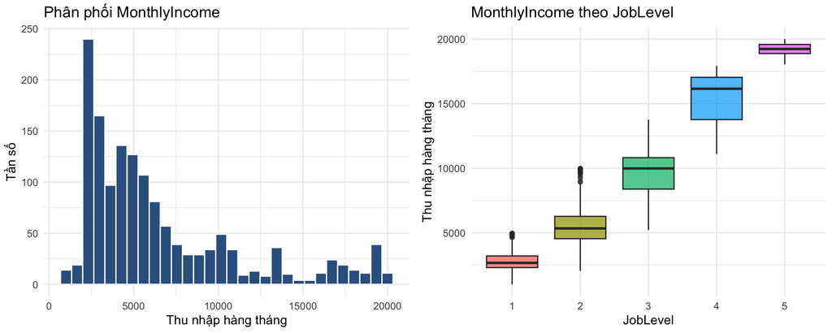

```r
p_income <- ggplot(df_model, aes(MonthlyIncome)) +
  geom_histogram(bins = 30, fill = "#35618f", color = "white") +
  theme_minimal() +
  labs(
    title = "Phân phối MonthlyIncome",
    x = "Thu nhập hàng tháng", y = "Tần số"
  )

p_level <- ggplot(df_model, aes(JobLevel, MonthlyIncome, fill = JobLevel)) +
  geom_boxplot(alpha = 0.75, outlier.alpha = 0.45) +
  theme_minimal() +
  theme(legend.position = "none") +
  labs(
    title = "MonthlyIncome theo JobLevel",
    x = "JobLevel", y = "Thu nhập hàng tháng"
  )

gridExtra::grid.arrange(p_income, p_level, ncol = 2)
```

# 2. Phân tích các yếu tố liên quan đến thu nhập

Phần này sử dụng toàn bộ dữ liệu để mô tả các mối liên hệ thống kê. Kết quả không được dùng để lựa chọn mô hình dự báo và không được diễn giải như quan hệ nhân quả.

## 2.1. Phân tích phương sai ANOVA nhiều nhân tố

```r
df_anova <- df_model
contrasts(df_anova$JobLevel) <- contr.sum(nlevels(df_anova$JobLevel))
contrasts(df_anova$Department) <- contr.sum(nlevels(df_anova$Department))
contrasts(df_anova$Gender) <- contr.sum(nlevels(df_anova$Gender))

anova_fit <- lm(
  MonthlyIncome ~ JobLevel * Department + Gender,
  data = df_anova
)

anova_type3_classical <- car::Anova(anova_fit, type = 3)
anova_type3_hc3 <- car::Anova(anova_fit, type = 3, white.adjust = "hc3")

anova_hc3_table <- as.data.frame(anova_type3_hc3) %>%
  rownames_to_column("Thành phần")
knitr::kable(
  anova_hc3_table,
  digits = 4,
  caption = "ANOVA Type III với ma trận hiệp phương sai HC3"
)
```

ANOVA Type III với ma trận hiệp phương sai HC3

| Thành phần | Df | F | Pr(>F) |
| --- | --- | --- | --- |
| (Intercept) | 1 | 18651.9048 | 0.0000 |
| JobLevel | 4 | 5852.4590 | 0.0000 |
| Department | 2 | 3.5823 | 0.0281 |
| Gender | 1 | 0.1968 | 0.6574 |
| JobLevel:Department | 8 | 4.9917 | 0.0000 |
| Residuals | 1454 | NA | NA |

```r
anova_effects <- effectsize::eta_squared(
  anova_type3_classical,
  partial = TRUE,
  ci = 0.95
)
knitr::kable(
  as.data.frame(anova_effects),
  digits = 4,
  caption = "Partial eta-squared và khoảng tin cậy"
)
```

Partial eta-squared và khoảng tin cậy

| Parameter | Eta2_partial | CI | CI_low | CI_high |
| --- | --- | --- | --- | --- |
| JobLevel | 0.8361 | 0.95 | 0.8257 | 1 |
| Department | 0.0044 | 0.95 | 0.0001 | 1 |
| Gender | 0.0001 | 0.95 | 0.0000 | 1 |
| JobLevel:Department | 0.0328 | 0.95 | 0.0153 | 1 |

Partial eta-squared được tính từ tổng bình phương cổ điển và chỉ mô tả quy mô liên hệ. Kết luận kiểm định chính vẫn dựa trên Type III với HC3.

Type III được dùng vì mô hình có tương tác và số quan sát giữa các tổ hợp `JobLevel x Department` không cân bằng. Khi tương tác có ý nghĩa, một “tác động chung” của `Department` không đủ để mô tả cấu trúc dữ liệu; cần xem chênh lệch phòng ban tại từng cấp bậc.

ANOVA dùng mã hóa tổng bằng `contr.sum`, nên không lấy một phòng ban hoặc giới làm nhóm tham chiếu duy nhất. Mỗi hiệu ứng được đánh giá quanh trung bình chung có điều chỉnh. Các so sánh cặp `emmeans` bên dưới nêu trực tiếp hai nhóm được so sánh.

```r
anova_vcov_hc3 <- sandwich::vcovHC(anova_fit, type = "HC3")
emm_department <- emmeans::emmeans(
  anova_fit,
  ~ Department | JobLevel,
  vcov. = anova_vcov_hc3,
  weights = "proportional"
)

emm_table <- as.data.frame(emm_department)
pair_table <- as.data.frame(
  pairs(emm_department, adjust = "tukey")
)

knitr::kable(
  emm_table,
  digits = 2,
  caption = "Thu nhập trung bình hiệu chỉnh theo Department trong từng JobLevel"
)
```

Thu nhập trung bình hiệu chỉnh theo Department trong từng JobLevel

| Department | JobLevel | emmean | SE | df | lower.CL | upper.CL |
| --- | --- | --- | --- | --- | --- | --- |
| Human Resources | 1 | 2730.27 | 125.14 | 1454 | 2484.80 | 2975.74 |
| Research & Development | 1 | 2838.69 | 36.67 | 1454 | 2766.77 | 2910.62 |
| Sales | 1 | 2508.56 | 73.56 | 1454 | 2364.26 | 2652.85 |
| Human Resources | 2 | 5558.33 | 269.01 | 1454 | 5030.64 | 6086.01 |
| Research & Development | 2 | 5291.63 | 80.80 | 1454 | 5133.13 | 5450.13 |
| Sales | 2 | 5746.69 | 94.81 | 1454 | 5560.70 | 5932.67 |
| Human Resources | 3 | 9626.03 | 463.32 | 1454 | 8717.19 | 10534.88 |
| Research & Development | 3 | 10172.93 | 175.36 | 1454 | 9828.94 | 10516.93 |
| Sales | 3 | 9280.75 | 154.44 | 1454 | 8977.81 | 9583.70 |
| Human Resources | 4 | 16150.53 | 851.84 | 1454 | 14479.56 | 17821.51 |
| Research & Development | 4 | 15636.37 | 221.21 | 1454 | 15202.44 | 16070.30 |
| Sales | 4 | 15170.19 | 324.09 | 1454 | 14534.46 | 15805.92 |
| Human Resources | 5 | 19194.39 | 224.14 | 1454 | 18754.72 | 19634.06 |
| Research & Development | 5 | 19216.28 | 69.41 | 1454 | 19080.12 | 19352.44 |
| Sales | 5 | 19089.87 | 183.19 | 1454 | 18730.53 | 19449.20 |

```r
knitr::kable(
  pair_table,
  digits = 3,
  caption = "So sánh Department trong từng JobLevel, điều chỉnh Tukey"
)
```

So sánh Department trong từng JobLevel, điều chỉnh Tukey

| contrast | JobLevel | estimate | SE | df | t.ratio | p.value |
| --- | --- | --- | --- | --- | --- | --- |
| Human Resources - Research & Development | 1 | -108.424 | 130.354 | 1454 | -0.832 | 0.683 |
| Human Resources - Sales | 1 | 221.711 | 145.343 | 1454 | 1.525 | 0.279 |
| Research & Development - Sales | 1 | 330.135 | 82.411 | 1454 | 4.006 | 0.000 |
| Human Resources - Research & Development | 2 | 266.701 | 281.068 | 1454 | 0.949 | 0.609 |
| Human Resources - Sales | 2 | -188.358 | 285.658 | 1454 | -0.659 | 0.787 |
| Research & Development - Sales | 2 | -455.059 | 124.447 | 1454 | -3.657 | 0.001 |
| Human Resources - Research & Development | 3 | -546.901 | 495.137 | 1454 | -1.105 | 0.511 |
| Human Resources - Sales | 3 | 345.279 | 488.647 | 1454 | 0.707 | 0.760 |
| Research & Development - Sales | 3 | 892.180 | 233.851 | 1454 | 3.815 | 0.000 |
| Human Resources - Research & Development | 4 | 514.162 | 879.868 | 1454 | 0.584 | 0.829 |
| Human Resources - Sales | 4 | 980.343 | 911.082 | 1454 | 1.076 | 0.529 |
| Research & Development - Sales | 4 | 466.181 | 392.028 | 1454 | 1.189 | 0.460 |
| Human Resources - Research & Development | 5 | -21.891 | 234.449 | 1454 | -0.093 | 0.995 |
| Human Resources - Sales | 5 | 104.524 | 289.590 | 1454 | 0.361 | 0.931 |
| Research & Development - Sales | 5 | 126.415 | 196.062 | 1454 | 0.645 | 0.795 |

Không bác bỏ hệ số giới tính không chứng minh doanh nghiệp đã đạt bình đẳng lương. Nó chỉ cho thấy mô hình hiện tại chưa phát hiện được chênh lệch trung bình theo giới sau khi điều chỉnh các biến trong công thức.

## 2.2. Mô hình hồi quy tuyến tính được xác định trước

Các biến trong mô hình dưới đây được chọn trước khi xem p-value, dựa trên mục tiêu nghiên cứu: cấp bậc, vai trò, kinh nghiệm, thời gian tại công ty, lịch sử công việc, giáo dục, hiệu suất và giới tính. `Department` đã được phân tích cùng tương tác ở phần ANOVA và không được đưa đồng thời với `JobRole` trong mô hình giải thích này.

```r
core_formula <- MonthlyIncome ~ JobLevel + JobRole + TotalWorkingYears +
  YearsAtCompany + NumCompaniesWorked + Education +
  PerformanceRating + Gender

ols_core <- lm(core_formula, data = df_model)
ols_summary <- summary(ols_core)
ols_vcov_hc3 <- sandwich::vcovHC(ols_core, type = "HC3")
ols_hc3 <- lmtest::coeftest(ols_core, vcov. = ols_vcov_hc3)
ols_global_hc3 <- car::linearHypothesis(
  ols_core,
  names(coef(ols_core))[-1],
  vcov. = ols_vcov_hc3,
  test = "F"
)

critical_t <- qt(0.975, df.residual(ols_core))
ols_hc3_table <- tibble(
  `Hệ số` = rownames(ols_hc3),
  Estimate = ols_hc3[, 1],
  `SE HC3` = ols_hc3[, 2],
  `t` = ols_hc3[, 3],
  `p` = ols_hc3[, 4],
  `CI 2.5%` = ols_hc3[, 1] - critical_t * ols_hc3[, 2],
  `CI 97.5%` = ols_hc3[, 1] + critical_t * ols_hc3[, 2]
)

ols_overall_table <- tibble(
  `Chỉ tiêu` = c(
    "Số quan sát", "R-squared", "R-squared hiệu chỉnh",
    "Sai số chuẩn phần dư", "Wald F với HC3", "p-value Wald HC3"
  ),
  `Kết quả` = c(
    nobs(ols_core),
    sprintf("%.4f", ols_summary$r.squared),
    sprintf("%.4f", ols_summary$adj.r.squared),
    sprintf("%.2f", ols_summary$sigma),
    sprintf("%.2f", ols_global_hc3$F[2]),
    format_p(ols_global_hc3$`Pr(>F)`[2])
  )
)

knitr::kable(
  ols_overall_table,
  caption = "Mức độ phù hợp tổng thể của mô hình OLS"
)
```

Mức độ phù hợp tổng thể của mô hình OLS

| Chỉ tiêu | Kết quả |
| --- | --- |
| Số quan sát | 1470 |
| R-squared | 0.9507 |
| R-squared hiệu chỉnh | 0.9499 |
| Sai số chuẩn phần dư | 1053.31 |
| Wald F với HC3 | 3088.77 |
| p-value Wald HC3 | <1e-16 |

```r
knitr::kable(
  ols_hc3_table,
  digits = 3,
  caption = "Hệ số OLS với sai số chuẩn và khoảng tin cậy HC3"
)
```

Hệ số OLS với sai số chuẩn và khoảng tin cậy HC3

| Hệ số | Estimate | SE HC3 | t | p | CI 2.5% | CI 97.5% |
| --- | --- | --- | --- | --- | --- | --- |
| (Intercept) | 3661.581 | 152.121 | 24.070 | 0.000 | 3363.181 | 3959.982 |
| JobLevel2 | 1627.533 | 119.939 | 13.570 | 0.000 | 1392.261 | 1862.805 |
| JobLevel3 | 4898.986 | 171.369 | 28.587 | 0.000 | 4562.828 | 5235.145 |
| JobLevel4 | 8458.357 | 217.530 | 38.884 | 0.000 | 8031.649 | 8885.065 |
| JobLevel5 | 11036.836 | 242.221 | 45.565 | 0.000 | 10561.694 | 11511.978 |
| JobRoleHealthcare Representative | -2.420 | 131.431 | -0.018 | 0.985 | -260.237 | 255.396 |
| JobRoleHuman Resources | -835.543 | 184.633 | -4.525 | 0.000 | -1197.720 | -473.366 |
| JobRoleLaboratory Technician | -1252.839 | 147.999 | -8.465 | 0.000 | -1543.154 | -962.523 |
| JobRoleManager | 3341.398 | 147.323 | 22.681 | 0.000 | 3052.409 | 3630.386 |
| JobRoleManufacturing Director | -80.190 | 125.826 | -0.637 | 0.524 | -327.010 | 166.630 |
| JobRoleResearch Director | 3373.347 | 150.306 | 22.443 | 0.000 | 3078.506 | 3668.188 |
| JobRoleResearch Scientist | -1177.204 | 139.250 | -8.454 | 0.000 | -1450.358 | -904.050 |
| JobRoleSales Representative | -1464.195 | 167.944 | -8.718 | 0.000 | -1793.635 | -1134.754 |
| TotalWorkingYears | 35.625 | 7.757 | 4.593 | 0.000 | 20.409 | 50.841 |
| YearsAtCompany | 3.249 | 6.537 | 0.497 | 0.619 | -9.573 | 16.072 |
| NumCompaniesWorked | 25.390 | 12.290 | 2.066 | 0.039 | 1.282 | 49.497 |
| Education1 | 145.147 | 95.988 | 1.512 | 0.131 | -43.143 | 333.438 |
| Education2 | -65.510 | 77.139 | -0.849 | 0.396 | -216.827 | 85.807 |
| Education4 | 89.016 | 71.346 | 1.248 | 0.212 | -50.935 | 228.968 |
| Education5 | -113.408 | 170.065 | -0.667 | 0.505 | -447.008 | 220.191 |
| PerformanceRating4 | -27.688 | 70.850 | -0.391 | 0.696 | -166.669 | 111.292 |
| GenderMale | 69.631 | 56.704 | 1.228 | 0.220 | -41.600 | 180.862 |

### Nhận xét mô hình OLS

Trong bảng hệ số, hệ số chặn đại diện cho hồ sơ thuộc toàn bộ nhóm tham chiếu khi các biến số bằng 0. Mỗi hệ số của biến phân loại là chênh lệch thu nhập so với nhóm tham chiếu tương ứng, sau khi giữ các biến khác không đổi.

- Mô hình phù hợp tổng thể cao và kiểm định Wald HC3 cho thấy tập biến có liên hệ rõ ràng với thu nhập. Tuy nhiên, $R^2$ cao không đồng nghĩa mọi hệ số riêng lẻ đều có ý nghĩa.
- `JobLevel` là nhóm biến nổi bật nhất: hệ số tăng đều từ Level 2 đến Level 5 so với Level 1. Điều này phù hợp với cấu trúc lương theo cấp bậc đã thấy trên biểu đồ hộp.
- Sau khi giữ các biến khác không đổi, các vị trí `Manager` và `Research Director` có hệ số dương lớn so với `Sales Executive`. `Laboratory Technician`, `Research Scientist` và `Sales Representative` có hệ số âm so với nhóm tham chiếu này. Các chênh lệch đó không phải mức lương tuyệt đối.
- `TotalWorkingYears` có hệ số dương và khoảng tin cậy không chứa 0, cho thấy tổng kinh nghiệm làm việc có liên hệ ổn định với thu nhập. Ngược lại, `YearsAtCompany` không còn ý nghĩa rõ ràng sau khi đã điều chỉnh cấp bậc, vai trò và tổng kinh nghiệm.
- Hệ số `GenderMale` so sánh `Male` với nhóm tham chiếu `Female`; hệ số `PerformanceRating4` so sánh mức 4 với mức 3. Hai hệ số này không có bằng chứng khác 0 sau điều chỉnh. Kết quả không đủ để kết luận chính sách lương hoàn toàn công bằng.
- Các hệ số `Education` so sánh từng trình độ với mức 3, tức `Bachelor`. Cần đọc từng khoảng tin cậy HC3 trước khi kết luận về khác biệt theo học vấn.

Sai số chuẩn HC3 được dùng khi phương sai phần dư thay đổi, làm cho sai số chuẩn cổ điển không còn đáng tin cậy. Cách điều chỉnh này không biến mối liên hệ quan sát thành quan hệ nhân quả.

## 2.3. Kiểm định các giả định của hồi quy tuyến tính

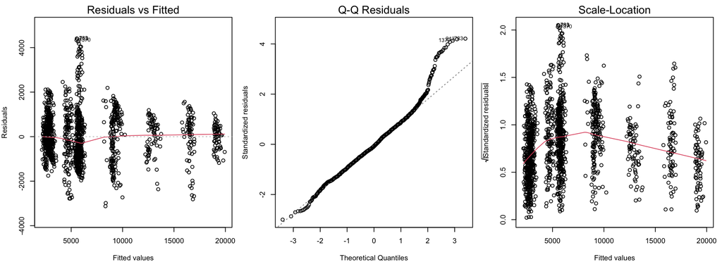

```r
par(mfrow = c(1, 3), mar = c(4, 4, 2, 1))
plot(ols_core, which = c(1, 2, 3))
```

```r
par(mfrow = c(1, 1))

bp_core <- lmtest::bptest(ols_core)
reset_core <- lmtest::resettest(ols_core, power = 2:3, type = "fitted")
shapiro_core <- shapiro.test(residuals(ols_core))

# VIF thông thường được tính trên từng cột của ma trận thiết kế.
# model.matrix() chuyển biến phân loại thành biến giả và bỏ một mức tham chiếu.
core_design <- model.matrix(ols_core)[, -1, drop = FALSE]
core_vif <- vapply(seq_len(ncol(core_design)), function(j) {
  auxiliary_fit <- lm(core_design[, j] ~ core_design[, -j, drop = FALSE])
  1 / (1 - summary(auxiliary_fit)$r.squared)
}, FUN.VALUE = numeric(1))

vif_table <- tibble(
  `Biến/cột biến giả` = colnames(core_design),
  VIF = core_vif,
  `Đánh giá` = case_when(
    VIF < 5 ~ "Không đáng kể",
    VIF < 10 ~ "Cần lưu ý",
    TRUE ~ "Nghiêm trọng"
  )
) %>% arrange(desc(VIF))

diagnostic_table <- tibble(
  `Giả định/chỉ tiêu` = c(
    "RESET: quan hệ tuyến tính",
    "Breusch–Pagan: phương sai đồng nhất",
    "Shapiro–Wilk: phần dư chuẩn"
  ),
  `Thống kê` = c(
    unname(reset_core$statistic),
    unname(bp_core$statistic),
    unname(shapiro_core$statistic)
  ),
  `p-value` = c(
    format_p(reset_core$p.value),
    format_p(bp_core$p.value),
    format_p(shapiro_core$p.value)
  )
)

knitr::kable(diagnostic_table, digits = 4, caption = "Kết quả kiểm định giả định OLS")
```

Kết quả kiểm định giả định OLS

| Giả định/chỉ tiêu | Thống kê | p-value |
| --- | --- | --- |
| RESET: quan hệ tuyến tính | 2.9678 | 0.0517 |
| Breusch–Pagan: phương sai đồng nhất | 129.3511 | <1e-16 |
| Shapiro–Wilk: phần dư chuẩn | 0.9732 | 6.42e-16 |

```r
knitr::kable(vif_table, digits = 3, caption = "VIF thông thường của các biến và cột biến giả")
```

VIF thông thường của các biến và cột biến giả

| Biến/cột biến giả | VIF | Đánh giá |
| --- | --- | --- |
| JobLevel4 | 4.629 | Không đáng kể |
| JobLevel5 | 4.212 | Không đáng kể |
| TotalWorkingYears | 3.843 | Không đáng kể |
| JobLevel3 | 3.819 | Không đáng kể |
| JobLevel2 | 3.623 | Không đáng kể |
| JobRoleResearch Scientist | 3.088 | Không đáng kể |
| JobRoleLaboratory Technician | 2.809 | Không đáng kể |
| JobRoleManager | 2.616 | Không đáng kể |
| YearsAtCompany | 1.932 | Không đáng kể |
| JobRoleResearch Director | 1.883 | Không đáng kể |
| JobRoleSales Representative | 1.822 | Không đáng kể |
| JobRoleHuman Resources | 1.328 | Không đáng kể |
| JobRoleManufacturing Director | 1.324 | Không đáng kể |
| JobRoleHealthcare Representative | 1.310 | Không đáng kể |
| Education4 | 1.269 | Không đáng kể |
| NumCompaniesWorked | 1.249 | Không đáng kể |
| Education2 | 1.228 | Không đáng kể |
| Education1 | 1.177 | Không đáng kể |
| Education5 | 1.068 | Không đáng kể |
| GenderMale | 1.019 | Không đáng kể |
| PerformanceRating4 | 1.010 | Không đáng kể |

```r
alpha_diagnostic <- 0.05
max_core_vif <- max(vif_table$VIF)

assumption_conclusion <- tibble(
  `Giả định/chỉ tiêu` = c(
    "Quan hệ tuyến tính",
    "Độc lập của sai số",
    "Phương sai đồng nhất",
    "Phần dư chuẩn",
    "Không đa cộng tuyến nghiêm trọng"
  ),
  `Kết luận` = c(
    if (reset_core$p.value < alpha_diagnostic) {
      "Vi phạm ở mức ý nghĩa 5%"
    } else if (reset_core$p.value < 0.10) {
      "Chưa vi phạm ở mức 5%, nhưng kết quả sát ngưỡng"
    } else {
      "Chưa phát hiện vi phạm"
    },
    "Chưa thể xác nhận từ dữ liệu chéo hiện có",
    if (bp_core$p.value < alpha_diagnostic) "Vi phạm" else "Chưa phát hiện vi phạm",
    if (shapiro_core$p.value < alpha_diagnostic) "Vi phạm" else "Chưa phát hiện vi phạm",
    if (max_core_vif < 5) "Đạt" else "Cần xem xét"
  ),
  `Xử lý/định hướng` = c(
    "Giữ dạng hiện tại; kiểm tra spline hoặc tương tác nếu dữ liệu mới cho kết quả khác",
    "Cần mã nhóm hoặc thời gian; dùng sai số chuẩn theo cụm hay mô hình hỗn hợp nếu cần",
    "Dùng sai số chuẩn HC3; cân nhắc WLS hoặc mô hình hóa phương sai",
    "Dùng HC3 hoặc bootstrap; thử biến đổi đáp ứng nhưng phải kiểm định lại",
    "Không loại biến chỉ vì đa cộng tuyến"
  )
)

knitr::kable(
  assumption_conclusion,
  caption = "Kết luận và hướng xử lý các giả định của mô hình OLS"
)
```

Kết luận và hướng xử lý các giả định của mô hình OLS

| Giả định/chỉ tiêu | Kết luận | Xử lý/định hướng |
| --- | --- | --- |
| Quan hệ tuyến tính | Chưa vi phạm ở mức 5%, nhưng kết quả sát ngưỡng | Giữ dạng hiện tại; kiểm tra spline hoặc tương tác nếu dữ liệu mới cho kết quả khác |
| Độc lập của sai số | Chưa thể xác nhận từ dữ liệu chéo hiện có | Cần mã nhóm hoặc thời gian; dùng sai số chuẩn theo cụm hay mô hình hỗn hợp nếu cần |
| Phương sai đồng nhất | Vi phạm | Dùng sai số chuẩn HC3; cân nhắc WLS hoặc mô hình hóa phương sai |
| Phần dư chuẩn | Vi phạm | Dùng HC3 hoặc bootstrap; thử biến đổi đáp ứng nhưng phải kiểm định lại |
| Không đa cộng tuyến nghiêm trọng | Đạt | Không loại biến chỉ vì đa cộng tuyến |

### Kết luận về chất lượng mô hình OLS

Mô hình OLS **tốt để làm mô hình cơ sở**, nhưng chưa thỏa hoàn toàn các giả định OLS cổ điển. Kết luận này dựa trên các kết quả sau:

1. **Quan hệ tuyến tính chưa bị bác bỏ, nhưng cần thận trọng.** RESET cho p-value bằng 0,0517, chỉ cao hơn mức ý nghĩa 5% một khoảng nhỏ. Vì vậy, chưa có đủ bằng chứng kết luận sai dạng hàm, nhưng kết quả đang sát ngưỡng. Nếu dữ liệu mới làm p-value giảm dưới 0,05, cần thử spline hoặc các tương tác khác dựa trên cơ sở nghiệp vụ.
2. **Chưa thể xác nhận tính độc lập.** Dữ liệu không có thứ tự thời gian, mã nhóm hoặc quan hệ quản lý để kiểm tra sự phụ thuộc giữa các quan sát. Durbin–Watson không phù hợp để tự động kết luận cho bộ dữ liệu chéo này. Khi có dữ liệu theo nhóm, nên dùng sai số chuẩn theo cụm hoặc mô hình hỗn hợp. Đây là hạn chế dữ liệu, không phải một giả định đã được chứng minh.
3. **Mô hình vi phạm giả định phương sai đồng nhất.** Breusch–Pagan có p-value nhỏ hơn $10^{-16}$, nên bác bỏ giả thuyết phương sai phần dư không đổi. Vì vậy, sai số chuẩn OLS thông thường không còn phù hợp để kiểm định hệ số. Báo cáo đã dùng HC3 cho sai số chuẩn, p-value và khoảng tin cậy. HC3 không làm phương sai trở nên đồng nhất; nó giúp suy luận vẫn đáng tin cậy khi phương sai thay đổi. Nếu cần mô hình hóa chính phương sai, có thể thử WLS hoặc GLS rồi kiểm định lại trên phần dư đã chuẩn hóa.
4. **Mô hình vi phạm giả định phần dư chuẩn.** Shapiro–Wilk có p-value bằng $6{,}42 \times 10^{-16}$, nên phần dư không tuân theo phân phối chuẩn. Q–Q plot cần được đọc cùng kết quả này để nhận diện sai lệch ở hai đuôi. Với 1.470 quan sát, vi phạm này ít ảnh hưởng đến ước lượng điểm hơn việc dùng sai số chuẩn sai. HC3 được giữ cho suy luận; bootstrap có thể được dùng nếu cần khoảng tin cậy ít phụ thuộc phân phối hơn.

**Về vấn đề đa cộng tuyến:** VIF lớn nhất bằng 4,629, thấp hơn ngưỡng 5. Vì vậy, không cần loại thêm biến vì đa cộng tuyến.

**Vì sao dùng VIF thông thường?** VIF được định nghĩa cho từng biến dự báo có một bậc tự do. Các biến phân loại như `JobLevel` hoặc `JobRole` được chuyển thành các cột biến giả bằng `model.matrix()`; một mức tham chiếu được bỏ để tránh bẫy biến giả. Nhờ đó, mỗi cột có VIF theo công thức $VIF_j=1/(1-R_j^2)$ và dùng ngưỡng quen thuộc: dưới 5 là không đáng kể, từ 5 đến dưới 10 cần lưu ý, và từ 10 trở lên là nghiêm trọng. Một biến phân loại có nhiều dòng VIF tương ứng với nhiều cột biến giả, vì vậy không tự động loại cả biến chỉ dựa trên một cột.

```r
ols_log_core <- lm(update(core_formula, log(MonthlyIncome) ~ .), data = df_model)
bp_log <- lmtest::bptest(ols_log_core)
shapiro_log <- shapiro.test(residuals(ols_log_core))

log_sensitivity <- tibble(
  `Mô hình` = c("OLS thang gốc", "OLS log(MonthlyIncome)"),
  `BP p-value` = c(bp_core$p.value, bp_log$p.value),
  `Shapiro p-value` = c(shapiro_core$p.value, shapiro_log$p.value),
  `Độ lệch phần dư` = c(
    mean((residuals(ols_core) - mean(residuals(ols_core)))^3) /
      sd(residuals(ols_core))^3,
    mean((residuals(ols_log_core) - mean(residuals(ols_log_core)))^3) /
      sd(residuals(ols_log_core))^3
  )
)
knitr::kable(log_sensitivity, digits = 5, caption = "Độ nhạy với biến đổi log")
```

Độ nhạy với biến đổi log

| Mô hình | BP p-value | Shapiro p-value | Độ lệch phần dư |
| --- | --- | --- | --- |
| OLS thang gốc | 0 | 0 | 0.61694 |
| OLS log(MonthlyIncome) | 0 | 0 | -0.24820 |

Biến đổi log làm độ lệch phần dư giảm từ 0,617 xuống -0,248. Tuy nhiên, cả Breusch–Pagan và Shapiro–Wilk vẫn có p-value rất nhỏ. Do đó, biến đổi log **không xử lý hết hai vi phạm** trong dữ liệu này và không được chọn chỉ để làm p-value vượt 0,05.

Báo cáo giữ OLS trên thang thu nhập gốc để dễ diễn giải, dùng HC3 cho suy luận và đánh giá khả năng dự báo riêng trên tập Test. Nếu mục tiêu là tìm mô hình thỏa giả định tốt hơn, cần thử WLS, GLS hoặc dạng phi tuyến trên tập Train, sau đó kiểm định lại và so sánh sai số trên tập Test.

# 3. Xây dựng mô hình dự báo và đánh giá mô hình

## 3.1. Chia tập Train/Test

```r
set.seed(SEED)
train_index <- caret::createDataPartition(
  df_model$MonthlyIncome,
  p = 0.70,
  list = FALSE
)

train_data <- droplevels(df_model[train_index, ])
test_data <- df_model[-train_index, ]

single_level_train <- vapply(
  train_data,
  function(x) is.factor(x) && nlevels(x) < 2,
  FUN.VALUE = logical(1)
)
if (any(single_level_train)) {
  removed_single_train <- names(train_data)[single_level_train]
  train_data <- train_data[, !single_level_train, drop = FALSE]
  test_data <- test_data[, !single_level_train, drop = FALSE]
}

factor_predictors <- setdiff(
  names(train_data)[vapply(train_data, is.factor, logical(1))],
  "MonthlyIncome"
)
novel_levels <- lapply(factor_predictors, function(v) {
  setdiff(unique(as.character(test_data[[v]])), levels(train_data[[v]]))
})
names(novel_levels) <- factor_predictors
stopifnot(all(lengths(novel_levels) == 0))

for (v in factor_predictors) {
  test_data[[v]] <- factor(test_data[[v]], levels = levels(train_data[[v]]))
}

dummy_encoder <- caret::dummyVars(
  MonthlyIncome ~ .,
  data = train_data, fullRank = TRUE
)
x_train <- predict(dummy_encoder, newdata = train_data)
x_test <- predict(dummy_encoder, newdata = test_data)
y_train <- train_data$MonthlyIncome
y_test <- test_data$MonthlyIncome

stopifnot(
  identical(colnames(x_train), colnames(x_test)),
  !anyNA(x_train), !anyNA(x_test),
  all(is.finite(x_train)), all(is.finite(x_test)),
  length(intersect(train_index, setdiff(seq_len(nrow(df_model)), train_index))) == 0
)

set.seed(SEED + 1L)
fold_id <- sample(rep(seq_len(10L), length.out = nrow(train_data)))
fold_segments <- lapply(seq_len(10L), function(k) which(fold_id == k))

split_table <- tibble(
  `Tập dữ liệu` = c("Train", "Test"),
  N = c(nrow(train_data), nrow(test_data)),
  `Tỷ lệ` = c(nrow(train_data), nrow(test_data)) / nrow(df_model)
)
knitr::kable(split_table, digits = 3, caption = "Phân chia dữ liệu")
```

Phân chia dữ liệu

| Tập dữ liệu | N | Tỷ lệ |
| --- | --- | --- |
| Train | 1031 | 0.701 |
| Test | 439 | 0.299 |

```r
cat("Số cột ma trận thiết kế:", ncol(x_train))
```

```
## Số cột ma trận thiết kế: 54
```

Tất cả bước mã hóa biến phân loại, chọn biến và lựa chọn tham số mô hình chỉ dùng tập Train. Tập Test chưa được dùng ở thời điểm này. Tỷ lệ Train/Test xấp xỉ 7/3.

## 3.2. Chọn quy trình bằng nested cross-validation trong tập Train

Nested CV dùng các fold ngoài để so sánh quy trình và các fold trong để chọn tham số. Nhờ đó, tập Test không quyết định mô hình cuối cùng.

```r
outer_train_indices <- local({
  set.seed(SEED + 30L)
  caret::createMultiFolds(y_train, k = 5, times = 3)
})

step_directions <- tibble(
  Model = c(
    "Forward–AIC", "Backward–AIC", "Hybrid–AIC",
    "Forward–BIC", "Backward–BIC", "Hybrid–BIC"
  ),
  Direction = c("forward", "backward", "both", "forward", "backward", "both"),
  Criterion = c("AIC", "AIC", "AIC", "BIC", "BIC", "BIC")
)

make_inner_folds <- function(y, seed_value) {
  set.seed(seed_value)
  fold_list <- caret::createFolds(y, k = 5, returnTrain = FALSE)
  fold_id_inner <- integer(length(y))
  for (j in seq_along(fold_list)) fold_id_inner[fold_list[[j]]] <- j
  list(id = fold_id_inner, segments = fold_list)
}

align_factor_levels <- function(analysis_data, assessment_data) {
  factor_names <- names(analysis_data)[
    vapply(analysis_data, is.factor, FUN.VALUE = logical(1))
  ]
  analysis_data <- droplevels(analysis_data)
  for (variable_name in factor_names) {
    unseen <- setdiff(
      unique(as.character(assessment_data[[variable_name]])),
      levels(analysis_data[[variable_name]])
    )
    if (length(unseen) > 0) {
      stop("Outer fold có mức phân loại mới ở biến ", variable_name)
    }
    assessment_data[[variable_name]] <- factor(
      assessment_data[[variable_name]],
      levels = levels(analysis_data[[variable_name]])
    )
  }
  list(analysis = analysis_data, assessment = assessment_data)
}

evaluate_outer_split <- function(analysis_id, split_name, split_number) {
  assessment_id <- setdiff(seq_len(nrow(train_data)), analysis_id)
  aligned <- align_factor_levels(
    train_data[analysis_id, , drop = FALSE],
    train_data[assessment_id, , drop = FALSE]
  )
  analysis_data <- aligned$analysis
  assessment_data <- aligned$assessment
  actual <- assessment_data$MonthlyIncome
  y_analysis <- analysis_data$MonthlyIncome
  inner <- make_inner_folds(y_analysis, SEED + 1000L + split_number)

  add_result <- function(model_name, prediction, complexity) {
    tibble(
      Split = split_name,
      Model = model_name,
      TrainRow = assessment_id,
      Actual = actual,
      Prediction = as.numeric(prediction),
      Complexity = as.numeric(complexity)
    )
  }

  result_parts <- list()
  result_parts[["mean"]] <- add_result(
    "Trung bình Train",
    rep(mean(y_analysis), length(actual)),
    0
  )

  joblevel_outer <- lm(MonthlyIncome ~ JobLevel, data = analysis_data)
  result_parts[["joblevel"]] <- add_result(
    "Chỉ dùng JobLevel",
    predict(joblevel_outer, newdata = assessment_data),
    joblevel_outer$rank - 1
  )

  ols_outer <- lm(MonthlyIncome ~ ., data = analysis_data)
  result_parts[["ols"]] <- add_result(
    "OLS",
    predict(ols_outer, newdata = assessment_data),
    ols_outer$rank - 1
  )

  log_outer <- lm(log(MonthlyIncome) ~ ., data = analysis_data)
  smearing_outer <- mean(exp(residuals(log_outer)))
  result_parts[["log_ols"]] <- add_result(
    "Log-OLS + Duan",
    exp(predict(log_outer, newdata = assessment_data)) * smearing_outer,
    log_outer$rank - 1
  )

  null_outer <- lm(MonthlyIncome ~ 1, data = analysis_data)
  outer_scope <- list(lower = formula(null_outer), upper = formula(ols_outer))
  for (j in seq_len(nrow(step_directions))) {
    start_model <- if (step_directions$Direction[j] == "backward") {
      ols_outer
    } else {
      null_outer
    }
    penalty <- if (step_directions$Criterion[j] == "AIC") {
      2
    } else {
      log(nrow(analysis_data))
    }
    step_outer <- step(
      start_model,
      scope = outer_scope,
      direction = step_directions$Direction[j],
      k = penalty,
      trace = 0
    )
    result_parts[[step_directions$Model[j]]] <- add_result(
      step_directions$Model[j],
      predict(step_outer, newdata = assessment_data),
      step_outer$rank - 1
    )
  }

  outer_encoder <- caret::dummyVars(
    MonthlyIncome ~ ., data = analysis_data, fullRank = TRUE
  )
  x_analysis <- predict(outer_encoder, newdata = analysis_data)
  x_assessment <- predict(outer_encoder, newdata = assessment_data)

  pcr_outer <- pls::pcr(
    MonthlyIncome ~ ., data = analysis_data,
    scale = TRUE, validation = "CV", segments = inner$segments
  )
  pcr_outer_rmsep <- drop(
    pls::RMSEP(pcr_outer, estimate = "CV")$val[1, 1, ]
  )
  pcr_outer_components <- which.min(pcr_outer_rmsep[-1])
  result_parts[["pcr"]] <- add_result(
    "PCR (CV nhỏ nhất)",
    drop(predict(
      pcr_outer,
      newdata = assessment_data,
      ncomp = pcr_outer_components
    )),
    pcr_outer_components
  )

  ridge_outer <- glmnet::cv.glmnet(
    x_analysis, y_analysis,
    alpha = 0, foldid = inner$id, standardize = TRUE
  )
  lasso_outer <- glmnet::cv.glmnet(
    x_analysis, y_analysis,
    alpha = 1, foldid = inner$id, standardize = TRUE
  )
  outer_elastic_alphas <- seq(0.1, 0.9, by = 0.1)
  elastic_outer_grid <- lapply(outer_elastic_alphas, function(alpha_value) {
    glmnet::cv.glmnet(
      x_analysis, y_analysis,
      alpha = alpha_value,
      foldid = inner$id,
      standardize = TRUE
    )
  })
  elastic_outer_index <- which.min(vapply(
    elastic_outer_grid,
    function(fit) min(fit$cvm),
    FUN.VALUE = numeric(1)
  ))
  elastic_outer <- elastic_outer_grid[[elastic_outer_index]]

  penalized_fits <- list(
    Ridge = ridge_outer,
    LASSO = lasso_outer,
    `Elastic-Net` = elastic_outer
  )
  for (model_name in names(penalized_fits)) {
    penalized_fit <- penalized_fits[[model_name]]
    active_count <- sum(
      as.matrix(coef(penalized_fit, s = "lambda.min"))[-1, 1] != 0
    )
    result_parts[[model_name]] <- add_result(
      model_name,
      drop(predict(
        penalized_fit,
        newx = x_assessment,
        s = "lambda.min"
      )),
      active_count
    )
  }

  bind_rows(result_parts)
}

nested_predictions <- purrr::imap_dfr(
  outer_train_indices,
  function(analysis_id, split_name) {
    split_number <- match(split_name, names(outer_train_indices))
    evaluate_outer_split(analysis_id, split_name, split_number)
  }
)

nested_split_metrics <- nested_predictions %>%
  group_by(Split, Model) %>%
  summarise(
    RMSE = metric_values(Actual, Prediction)["RMSE"],
    MAE = metric_values(Actual, Prediction)["MAE"],
    Complexity = first(Complexity),
    .groups = "drop"
  )

nested_summary <- nested_split_metrics %>%
  group_by(Model) %>%
  summarise(
    `RMSE trung bình` = mean(RMSE),
    `SE của RMSE` = sd(RMSE) / sqrt(n()),
    `MAE trung bình` = mean(MAE),
    `Độ phức tạp trung bình` = mean(Complexity),
    .groups = "drop"
  )

best_nested_row <- nested_summary %>%
  slice_min(`RMSE trung bình`, n = 1, with_ties = FALSE)
one_se_limit <- best_nested_row$`RMSE trung bình` + best_nested_row$`SE của RMSE`

selection_priority <- c(
  "Hybrid–BIC", "Forward–BIC", "Backward–BIC",
  "Hybrid–AIC", "Forward–AIC", "Backward–AIC",
  "LASSO", "Elastic-Net", "PCR (CV nhỏ nhất)",
  "Ridge", "OLS", "Log-OLS + Duan",
  "Chỉ dùng JobLevel", "Trung bình Train"
)

nested_summary <- nested_summary %>%
  mutate(
    `Trong ngưỡng một SE` = `RMSE trung bình` <= one_se_limit,
    Priority = match(Model, selection_priority)
  ) %>%
  arrange(`RMSE trung bình`)

selected_nested_row <- nested_summary %>%
  filter(`Trong ngưỡng một SE`) %>%
  arrange(`Độ phức tạp trung bình`, `MAE trung bình`, Priority) %>%
  slice(1)

final_procedure_name <- selected_nested_row$Model

knitr::kable(
  nested_summary %>% select(-Priority),
  digits = 2,
  caption = "Kết quả nested CV trong tập Train và quy tắc một sai số chuẩn"
)
```

Kết quả nested CV trong tập Train và quy tắc một sai số chuẩn

| Model | RMSE trung bình | SE của RMSE | MAE trung bình | Độ phức tạp trung bình | Trong ngưỡng một SE |
| --- | --- | --- | --- | --- | --- |
| Backward–BIC | 1067.15 | 21.51 | 822.92 | 13.07 | TRUE |
| Forward–BIC | 1067.15 | 21.51 | 822.92 | 13.07 | TRUE |
| Hybrid–BIC | 1067.15 | 21.51 | 822.92 | 13.07 | TRUE |
| LASSO | 1078.60 | 21.75 | 839.45 | 28.00 | TRUE |
| Elastic-Net | 1079.31 | 21.77 | 840.36 | 28.13 | TRUE |
| Forward–AIC | 1079.49 | 21.58 | 832.79 | 17.60 | TRUE |
| Hybrid–AIC | 1079.49 | 21.58 | 832.79 | 17.60 | TRUE |
| Backward–AIC | 1079.49 | 21.58 | 832.79 | 17.60 | TRUE |
| PCR (CV nhỏ nhất) | 1093.41 | 21.14 | 843.99 | 51.13 | FALSE |
| OLS | 1095.07 | 20.86 | 844.96 | 54.00 | FALSE |
| Ridge | 1171.45 | 22.69 | 927.07 | 54.00 | FALSE |
| Log-OLS + Duan | 1227.57 | 23.98 | 922.43 | 54.00 | FALSE |
| Chỉ dùng JobLevel | 1307.57 | 17.18 | 963.62 | 4.00 | FALSE |
| Trung bình Train | 4763.63 | 46.39 | 3681.89 | 0.00 | FALSE |

```r
cat("Mô hình được lựa chọn hoàn toàn trên Train:", final_procedure_name)
```

```
## Mô hình được lựa chọn hoàn toàn trên Train: Hybrid–BIC
```

Quy trình lựa chọn trên Train dùng quy tắc một sai số chuẩn và tính gọn. RMSE Test chỉ dùng để đánh giá khả năng khái quát hóa của mô hình. SE được ước lượng từ 15 outer assessments và dùng như quy tắc thực hành. Các fold lặp có phụ thuộc, nên không diễn giải SE như kiểm định độc lập.

## 3.3. Mô hình cơ sở, OLS và PCR

```r
pred_mean <- rep(mean(y_train), length(y_test))

joblevel_fit <- lm(MonthlyIncome ~ JobLevel, data = train_data)
pred_joblevel <- predict(joblevel_fit, newdata = test_data)

ols_full <- lm(MonthlyIncome ~ ., data = train_data)
pred_ols <- predict(ols_full, newdata = test_data)

set.seed(SEED + 2L)
pcr_fit <- pls::pcr(
  MonthlyIncome ~ .,
  data = train_data,
  scale = TRUE, validation = "CV", segments = fold_segments
)

pcr_rmsep <- drop(pls::RMSEP(pcr_fit, estimate = "CV")$val[1, 1, ])
k_pcr_min <- which.min(pcr_rmsep[-1])
k_pcr_1se <- pls::selectNcomp(pcr_fit, method = "onesigma", plot = FALSE)
if (is.na(k_pcr_1se) || k_pcr_1se < 1) k_pcr_1se <- k_pcr_min

pred_pcr_min <- drop(predict(pcr_fit, newdata = test_data, ncomp = k_pcr_min))
pred_pcr_1se <- drop(predict(pcr_fit, newdata = test_data, ncomp = k_pcr_1se))

pcr_selection <- tibble(
  `Quy tắc` = c("CV minimum", "One-sigma"),
  `Số thành phần` = c(k_pcr_min, k_pcr_1se),
  `RMSEP CV` = c(
    pcr_rmsep[k_pcr_min + 1],
    pcr_rmsep[k_pcr_1se + 1]
  )
)
knitr::kable(pcr_selection, digits = 2, caption = "Lựa chọn số thành phần PCR")
```

Lựa chọn số thành phần PCR

| Quy tắc | Số thành phần | RMSEP CV |
| --- | --- | --- |
| CV minimum | 51 | 1097.11 |
| One-sigma | 51 | 1097.11 |

Mô hình chỉ dùng `JobLevel` cho biết một biến nghiệp vụ đơn giản có thể dự báo được bao nhiêu. PCR được báo cáo ở cả điểm sai số kiểm định chéo nhỏ nhất và quy tắc một sai số chuẩn; bảng dự báo chính dùng điểm sai số nhỏ nhất để so sánh nhất quán với các mô hình khác.

## 3.4. Chọn biến bằng các phương pháp Forward, Backward và Hybrid selection

Ba phương pháp lựa chọn biến được thực hiện trên cùng một phạm vi mô hình:

- **Forward:** bắt đầu từ mô hình chỉ có hệ số chặn và lần lượt thêm biến.
- **Backward:** bắt đầu từ mô hình đầy đủ và lần lượt loại biến.
- **Hybrid:** sau mỗi bước có thể thêm hoặc loại biến.

### Cơ sở lựa chọn mức phạt AIC và BIC

Trong `stats::step()`, `k` là **mức phạt cho mỗi tham số**, không phải ngưỡng p-value hay ngưỡng thêm biến. Với $p$ tham số và hàm hợp lý $L$:

$$\mathrm{AIC}=-2\log L+2p,$$

$$\mathrm{BIC}=-2\log L+p\log(n_{Train}).$$

Mức phạt 2 thuộc định nghĩa AIC của [Akaike (1974)](https://doi.org/10.1109/TAC.1974.1100705). AIC ước lượng tổn thất thông tin kỳ vọng và thường hướng đến khả năng dự báo. Mức phạt `log(n_Train)` thuộc tiêu chuẩn của [Schwarz (1978)](https://doi.org/10.1214/aos/1176344136). Nó xuất phát từ xấp xỉ xác suất mô hình Bayes và tăng theo kích thước mẫu.

```r
null_model <- lm(MonthlyIncome ~ 1, data = train_data)
step_scope <- list(
  lower = formula(null_model),
  upper = formula(ols_full)
)
bic_penalty <- log(nrow(train_data))

penalty_table <- tibble(
  `Tiêu chí` = c("AIC", "BIC"),
  `Mức phạt trên mỗi tham số` = c(2, bic_penalty),
  `Số quan sát dùng tính mức phạt` = c(NA_integer_, nrow(train_data))
)
knitr::kable(
  penalty_table,
  digits = 3,
  caption = "Mức phạt AIC và BIC dùng trong Stepwise"
)
```

Mức phạt AIC và BIC dùng trong Stepwise

| Tiêu chí | Mức phạt trên mỗi tham số | Số quan sát dùng tính mức phạt |
| --- | --- | --- |
| AIC | 2.000 | NA |
| BIC | 6.938 | 1031 |

```r
step_forward_aic <- step(
  null_model,
  scope = step_scope,
  direction = "forward", k = 2, trace = 0
)
step_backward_aic <- step(
  ols_full,
  scope = step_scope,
  direction = "backward", k = 2, trace = 0
)
step_hybrid_aic <- step(
  null_model,
  scope = step_scope,
  direction = "both", k = 2, trace = 0
)

step_forward_bic <- step(
  null_model,
  scope = step_scope,
  direction = "forward", k = bic_penalty, trace = 0
)
step_backward_bic <- step(
  ols_full,
  scope = step_scope,
  direction = "backward", k = bic_penalty, trace = 0
)
step_hybrid_bic <- step(
  null_model,
  scope = step_scope,
  direction = "both", k = bic_penalty, trace = 0
)

step_models <- list(
  `Forward–AIC` = step_forward_aic,
  `Backward–AIC` = step_backward_aic,
  `Hybrid–AIC` = step_hybrid_aic,
  `Forward–BIC` = step_forward_bic,
  `Backward–BIC` = step_backward_bic,
  `Hybrid–BIC` = step_hybrid_bic
)

stepwise_table <- purrr::imap_dfr(step_models, function(model, model_name) {
  selected_terms <- attr(terms(model), "term.labels")
  tibble(
    `Phương pháp` = model_name,
    `Số biến` = length(selected_terms),
    `Các biến được chọn` = paste(selected_terms, collapse = ", "),
    AIC = AIC(model),
    BIC = BIC(model)
  )
})

knitr::kable(
  stepwise_table,
  digits = 2,
  caption = "Kết quả chọn biến bằng Forward, Backward và Hybrid"
)
```

Kết quả chọn biến bằng Forward, Backward và Hybrid

| Phương pháp | Số biến | Các biến được chọn | AIC | BIC |
| --- | --- | --- | --- | --- |
| Forward–AIC | 4 | JobLevel, JobRole, TotalWorkingYears, NumCompaniesWorked | 17307.25 | 17386.27 |
| Backward–AIC | 4 | JobLevel, JobRole, NumCompaniesWorked, TotalWorkingYears | 17307.25 | 17386.27 |
| Hybrid–AIC | 4 | JobLevel, JobRole, TotalWorkingYears, NumCompaniesWorked | 17307.25 | 17386.27 |
| Forward–BIC | 3 | JobLevel, JobRole, TotalWorkingYears | 17310.05 | 17384.12 |
| Backward–BIC | 3 | JobLevel, JobRole, TotalWorkingYears | 17310.05 | 17384.12 |
| Hybrid–BIC | 3 | JobLevel, JobRole, TotalWorkingYears | 17310.05 | 17384.12 |

```r
pred_step_aic <- predict(step_hybrid_aic, newdata = test_data)
pred_step_bic <- predict(step_hybrid_bic, newdata = test_data)
```

Trong bộ dữ liệu này, ba hướng tìm kiếm hội tụ về cùng một tập biến đối với từng tiêu chí. Vì vậy, phần đánh giá trên tập Test chỉ dùng Hybrid–AIC và Hybrid–BIC làm hai mô hình đại diện, tránh lặp lại các dự báo giống nhau.

Không sử dụng p-value hoặc kết quả trên tập Test để quyết định thêm hay loại biến. P-value của mô hình sau Stepwise chỉ mang tính tham khảo vì công thức mô hình đã được lựa chọn từ chính dữ liệu Train.

### Nhận xét các mô hình Stepwise

- Cả Forward, Backward và Hybrid đều đi đến cùng một kết quả trong từng tiêu chí. Điều này cho thấy tập biến được chọn không phụ thuộc vào hướng bắt đầu của thuật toán trong bộ dữ liệu hiện tại.
- Cả AIC và BIC đều giữ `JobLevel`, `JobRole` và `TotalWorkingYears`. Đây là ba nhóm thông tin xuất hiện nhất quán, phù hợp với nhận xét từ ANOVA và mô hình OLS.
- AIC giữ thêm `NumCompaniesWorked`, trong khi BIC loại biến này vì BIC phạt số lượng tham số mạnh hơn. Do đó, mô hình BIC dễ diễn giải và tiết kiệm biến hơn.
- Stepwise giúp tạo mô hình gọn nhưng có thể không ổn định khi dữ liệu thay đổi.

## 3.5. Ridge, LASSO và Elastic-Net

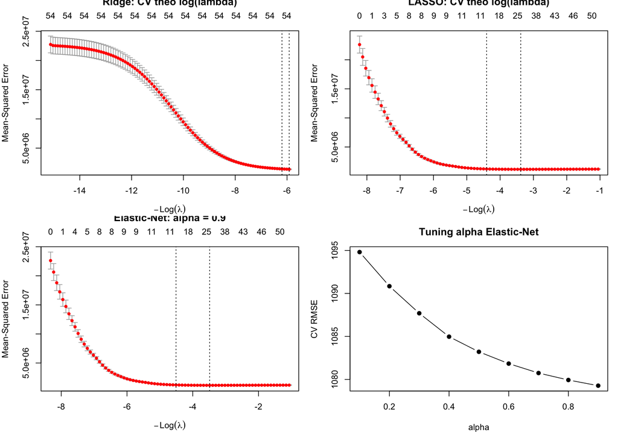

```r
cv_ridge <- glmnet::cv.glmnet(
  x_train, y_train,
  alpha = 0,
  foldid = fold_id, standardize = TRUE
)
cv_lasso <- glmnet::cv.glmnet(
  x_train, y_train,
  alpha = 1,
  foldid = fold_id, standardize = TRUE
)

elastic_alphas <- seq(0.1, 0.9, by = 0.1)
cv_elastic_grid <- lapply(elastic_alphas, function(a) {
  glmnet::cv.glmnet(
    x_train, y_train,
    alpha = a,
    foldid = fold_id, standardize = TRUE
  )
})
elastic_cv_min <- vapply(
  cv_elastic_grid,
  function(fit) min(fit$cvm),
  FUN.VALUE = numeric(1)
)
best_elastic_index <- which.min(elastic_cv_min)
best_elastic_alpha <- elastic_alphas[best_elastic_index]
cv_elastic <- cv_elastic_grid[[best_elastic_index]]

par(mfrow = c(2, 2), mar = c(4, 4, 3, 1))
plot(cv_ridge)
title("Ridge: CV theo log(lambda)", line = 2.5)
plot(cv_lasso)
title("LASSO: CV theo log(lambda)", line = 2.5)
plot(cv_elastic)
title(
  paste0("Elastic-Net: alpha = ", best_elastic_alpha),
  line = 2.5
)
plot(elastic_alphas, sqrt(elastic_cv_min),
  type = "b", pch = 19,
  xlab = "alpha", ylab = "CV RMSE", main = "Tuning alpha Elastic-Net"
)
```

```r
par(mfrow = c(1, 1))

pred_ridge_min <- drop(predict(cv_ridge, newx = x_test, s = "lambda.min"))
pred_ridge_1se <- drop(predict(cv_ridge, newx = x_test, s = "lambda.1se"))
pred_lasso_min <- drop(predict(cv_lasso, newx = x_test, s = "lambda.min"))
pred_lasso_1se <- drop(predict(cv_lasso, newx = x_test, s = "lambda.1se"))
pred_elastic_min <- drop(predict(cv_elastic, newx = x_test, s = "lambda.min"))
pred_elastic_1se <- drop(predict(cv_elastic, newx = x_test, s = "lambda.1se"))

tuning_table <- tibble(
  `Mô hình` = c("Ridge", "LASSO", "Elastic-Net"),
  alpha = c(0, 1, best_elastic_alpha),
  `lambda.min` = c(
    cv_ridge$lambda.min, cv_lasso$lambda.min, cv_elastic$lambda.min
  ),
  `lambda.1se` = c(
    cv_ridge$lambda.1se, cv_lasso$lambda.1se, cv_elastic$lambda.1se
  ),
  `CV RMSE tại lambda.min` = sqrt(c(
    min(cv_ridge$cvm), min(cv_lasso$cvm), min(cv_elastic$cvm)
  )),
  `Số hệ số khác 0 tại min` = c(
    sum(as.matrix(coef(cv_ridge, s = "lambda.min"))[-1, 1] != 0),
    sum(as.matrix(coef(cv_lasso, s = "lambda.min"))[-1, 1] != 0),
    sum(as.matrix(coef(cv_elastic, s = "lambda.min"))[-1, 1] != 0)
  )
)
knitr::kable(tuning_table, digits = 4, caption = "Kết quả lựa chọn tham số trên tập Train")
```

Kết quả lựa chọn tham số trên tập Train

| Mô hình | alpha | lambda.min | lambda.1se | CV RMSE tại lambda.min | Số hệ số khác 0 tại min |
| --- | --- | --- | --- | --- | --- |
| Ridge | 0.0 | 371.0090 | 490.4520 | 1174.640 | 54 |
| LASSO | 1.0 | 29.4018 | 81.8123 | 1078.716 | 25 |
| Elastic-Net | 0.9 | 32.6687 | 90.9026 | 1079.271 | 25 |

- **Ridge** dùng phạt L2 để làm nhỏ mọi hệ số, nhưng thường không đưa hệ số về đúng 0. Phương pháp này hữu ích khi nhiều biến tương quan.
- **LASSO** dùng phạt L1, có thể đưa hệ số ít hữu ích về 0 và thực hiện chọn biến. Khi các biến tương quan mạnh, biến được giữ có thể thay đổi giữa các mẫu.
- **Elastic-Net** kết hợp L1 và L2. Nó vừa chọn biến, vừa xử lý các nhóm biến tương quan ổn định hơn LASSO. Tham số `alpha` quyết định tỷ lệ kết hợp và được chọn bằng kiểm định chéo trên tập Train.

Mỗi phương pháp biến đổi hệ số khác nhau. Vì vậy, cần thận trọng khi diễn giải các hệ số ở phần sau.

```r
criteria_table <- tibble(
  `Phương pháp` = c(
    "Forward / Backward / Hybrid",
    "PCR", "Ridge", "LASSO", "Elastic-Net"
  ),
  `Tiêu chí lựa chọn` = c(
    "AIC hoặc BIC trên tập Train",
    "RMSEP qua kiểm định chéo; điểm nhỏ nhất và quy tắc một sai số chuẩn",
    "CV-RMSE để chọn lambda.min hoặc lambda.1se",
    "CV-RMSE và hệ số khác 0; kiểm tra thêm độ ổn định bằng lấy mẫu lặp",
    "CV-RMSE để chọn đồng thời alpha và lambda"
  ),
  `Vai trò của tập Test` = "Chỉ đánh giá mô hình sau khi đã lựa chọn"
)
knitr::kable(criteria_table, caption = "Tiêu chí lựa chọn của từng phương pháp")
```

Tiêu chí lựa chọn của từng phương pháp

| Phương pháp | Tiêu chí lựa chọn | Vai trò của tập Test |
| --- | --- | --- |
| Forward / Backward / Hybrid | AIC hoặc BIC trên tập Train | Chỉ đánh giá mô hình sau khi đã lựa chọn |
| PCR | RMSEP qua kiểm định chéo; điểm nhỏ nhất và quy tắc một sai số chuẩn | Chỉ đánh giá mô hình sau khi đã lựa chọn |
| Ridge | CV-RMSE để chọn lambda.min hoặc lambda.1se | Chỉ đánh giá mô hình sau khi đã lựa chọn |
| LASSO | CV-RMSE và hệ số khác 0; kiểm tra thêm độ ổn định bằng lấy mẫu lặp | Chỉ đánh giá mô hình sau khi đã lựa chọn |
| Elastic-Net | CV-RMSE để chọn đồng thời alpha và lambda | Chỉ đánh giá mô hình sau khi đã lựa chọn |

## 3.6. Đánh giá một lần trên tập Test

```r
log_ols_full <- lm(log(MonthlyIncome) ~ ., data = train_data)
duan_smearing <- mean(exp(residuals(log_ols_full)))
pred_log_ols <- exp(predict(log_ols_full, newdata = test_data)) * duan_smearing

step_test_predictions <- lapply(
  step_models[c("Hybrid–AIC", "Hybrid–BIC")],
  function(model) predict(model, newdata = test_data)
)

predictions_primary <- c(list(
  `Trung bình Train` = pred_mean,
  `Chỉ dùng JobLevel` = pred_joblevel,
  OLS = pred_ols
), step_test_predictions, list(
  `PCR (CV nhỏ nhất)` = pred_pcr_min,
  Ridge = pred_ridge_min,
  LASSO = pred_lasso_min,
  `Elastic-Net` = pred_elastic_min,
  `Log-OLS + Duan` = pred_log_ols
))

stopifnot(final_procedure_name %in% names(predictions_primary))

metrics_primary <- t(vapply(
  predictions_primary,
  function(p) metric_values(y_test, p),
  FUN.VALUE = c(RMSE = 0, MAE = 0, R2 = 0)
)) %>%
  as.data.frame() %>%
  rownames_to_column("Mô hình") %>%
  arrange(RMSE)

knitr::kable(
  metrics_primary,
  digits = 3,
  caption = "Hiệu suất dự báo trên tập Test"
)
```

Hiệu suất dự báo trên tập Test

| Mô hình | RMSE | MAE | R2 |
| --- | --- | --- | --- |
| Hybrid–BIC | 1042.196 | 788.864 | 0.948 |
| Hybrid–AIC | 1043.616 | 790.342 | 0.948 |
| LASSO | 1053.704 | 807.182 | 0.947 |
| Elastic-Net | 1054.346 | 808.355 | 0.947 |
| PCR (CV nhỏ nhất) | 1069.071 | 818.830 | 0.945 |
| OLS | 1072.314 | 822.021 | 0.945 |
| Log-OLS + Duan | 1132.745 | 848.369 | 0.938 |
| Ridge | 1167.530 | 929.522 | 0.934 |
| Chỉ dùng JobLevel | 1255.387 | 928.458 | 0.924 |
| Trung bình Train | 4563.754 | 3557.668 | -0.001 |

```r
predictions_parsimonious <- list(
  `PCR quy tắc một sai số chuẩn` = pred_pcr_1se,
  `Ridge lambda.1se` = pred_ridge_1se,
  `LASSO lambda.1se` = pred_lasso_1se,
  `Elastic-Net lambda.1se` = pred_elastic_1se
)

metrics_parsimonious <- t(vapply(
  predictions_parsimonious,
  function(p) metric_values(y_test, p),
  FUN.VALUE = c(RMSE = 0, MAE = 0, R2 = 0)
)) %>%
  as.data.frame() %>%
  rownames_to_column("Mô hình")

knitr::kable(
  metrics_parsimonious,
  digits = 3,
  caption = "Các phương án tinh gọn theo quy tắc một sai số chuẩn"
)
```

Các phương án tinh gọn theo quy tắc một sai số chuẩn

| Mô hình | RMSE | MAE | R2 |
| --- | --- | --- | --- |
| PCR quy tắc một sai số chuẩn | 1069.071 | 818.830 | 0.945 |
| Ridge lambda.1se | 1197.405 | 956.456 | 0.931 |
| LASSO lambda.1se | 1088.442 | 842.901 | 0.943 |
| Elastic-Net lambda.1se | 1091.804 | 846.307 | 0.943 |

RMSE nhấn mạnh sai số lớn, còn MAE phản ánh sai số tuyệt đối điển hình. $R^2$ Test đo cải thiện so với trung bình của chính tập Test.

Nested CV đã hoàn tất việc chọn mô hình chỉ bằng dữ liệu Train. Thứ hạng Test chỉ dùng để đánh giá, không dùng để chọn lại mô hình.

### Nhận xét khả năng dự báo của các mô hình hồi quy

```r
log_prediction_table <- rbind(
  `OLS thang gốc` = metric_values(y_test, pred_ols),
  `Log-OLS + Duan smearing` = metric_values(y_test, pred_log_ols)
) %>%
  as.data.frame() %>%
  rownames_to_column("Mô hình")
knitr::kable(
  log_prediction_table,
  digits = 3,
  caption = "Độ nhạy dự báo với biến đổi log"
)
```

Độ nhạy dự báo với biến đổi log

| Mô hình | RMSE | MAE | R2 |
| --- | --- | --- | --- |
| OLS thang gốc | 1072.314 | 822.021 | 0.945 |
| Log-OLS + Duan smearing | 1132.745 | 848.369 | 0.938 |

Biến đổi log chỉ được chọn nếu vừa cải thiện chẩn đoán phần dư vừa mang lại đánh đổi dự báo phù hợp trên thang thu nhập gốc; nó không được chọn chỉ vì biến phản hồi lệch phải.

## 3.7. Độ bất định trên tập Test cố định

```r
reference_model <- final_procedure_name
reference_prediction <- predictions_primary[[reference_model]]

set.seed(SEED + 10L)
bootstrap_ids <- replicate(
  B_TEST,
  sample.int(length(y_test), replace = TRUE)
)

bootstrap_summary <- lapply(names(predictions_primary), function(model_name) {
  model_prediction <- predictions_primary[[model_name]]
  boot_values <- apply(bootstrap_ids, 2, function(ii) {
    model_metrics <- metric_values(y_test[ii], model_prediction[ii])
    ref_metrics <- metric_values(y_test[ii], reference_prediction[ii])
    c(
      RMSE = unname(model_metrics["RMSE"]),
      MAE = unname(model_metrics["MAE"]),
      Delta_RMSE = unname(model_metrics["RMSE"] - ref_metrics["RMSE"]),
      Delta_MAE = unname(model_metrics["MAE"] - ref_metrics["MAE"])
    )
  })

  tibble(
    `Mô hình` = model_name,
    `RMSE CI 95%` = sprintf(
      "[%.1f; %.1f]",
      quantile(boot_values["RMSE", ], 0.025),
      quantile(boot_values["RMSE", ], 0.975)
    ),
    `MAE CI 95%` = sprintf(
      "[%.1f; %.1f]",
      quantile(boot_values["MAE", ], 0.025),
      quantile(boot_values["MAE", ], 0.975)
    ),
    `Delta RMSE so với mô hình cuối cùng` =
      metric_values(y_test, model_prediction)["RMSE"] -
        metric_values(y_test, reference_prediction)["RMSE"],
    `Delta RMSE CI 95%` = sprintf(
      "[%.1f; %.1f]",
      quantile(boot_values["Delta_RMSE", ], 0.025),
      quantile(boot_values["Delta_RMSE", ], 0.975)
    ),
    `Delta MAE CI 95%` = sprintf(
      "[%.1f; %.1f]",
      quantile(boot_values["Delta_MAE", ], 0.025),
      quantile(boot_values["Delta_MAE", ], 0.975)
    )
  )
}) %>% bind_rows()

knitr::kable(
  bootstrap_summary,
  digits = 2,
  caption = paste0(
    "Bootstrap ghép cặp trên Test cố định; mô hình tham chiếu: ",
    reference_model
  )
)
```

Bootstrap ghép cặp trên Test cố định; mô hình tham chiếu: Hybrid–BIC

| Mô hình | RMSE CI 95% | MAE CI 95% | Delta RMSE so với mô hình cuối cùng | Delta RMSE CI 95% | Delta MAE CI 95% |
| --- | --- | --- | --- | --- | --- |
| Trung bình Train | [4187.8; 4938.6] | [3294.5; 3838.2] | 3521.56 | [3117.8; 3920.2] | [2478.6; 3057.4] |
| Chỉ dùng JobLevel | [1141.1; 1367.2] | [850.2; 1009.0] | 213.19 | [141.4; 294.4] | [82.7; 199.0] |
| OLS | [979.2; 1173.4] | [760.4; 887.3] | 30.12 | [14.1; 46.4] | [15.6; 51.5] |
| Hybrid–AIC | [949.2; 1146.3] | [728.1; 855.6] | 1.42 | [-4.7; 7.3] | [-5.3; 7.9] |
| Hybrid–BIC | [947.5; 1142.5] | [726.6; 854.1] | 0.00 | [0.0; 0.0] | [0.0; 0.0] |
| PCR (CV nhỏ nhất) | [975.6; 1170.5] | [757.7; 885.0] | 26.87 | [10.9; 43.2] | [12.9; 48.2] |
| Ridge | [1075.9; 1261.9] | [866.1; 994.0] | 125.33 | [89.4; 163.1] | [103.4; 178.0] |
| LASSO | [959.4; 1157.5] | [745.1; 873.0] | 11.51 | [0.3; 23.0] | [6.4; 30.4] |
| Elastic-Net | [959.8; 1158.2] | [746.4; 873.8] | 12.15 | [0.5; 23.8] | [7.2; 31.9] |
| Log-OLS + Duan | [1032.5; 1238.2] | [784.3; 920.5] | 90.55 | [48.8; 137.0] | [26.7; 96.9] |

Khoảng tin cậy này giữ nguyên Train, mô hình và lần chia dữ liệu. Nó chỉ phản ánh biến động do thành phần quan sát trong tập Test cố định. Biến động huấn luyện được thể hiện bằng các outer fold của nested CV.

Nếu khoảng chênh RMSE chứa 0, chưa có bằng chứng rõ về khác biệt hiệu suất so với mô hình cuối cùng.

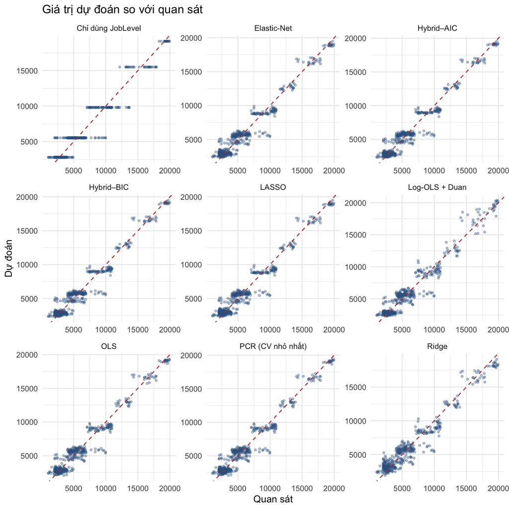

```r
plot_models <- setdiff(names(predictions_primary), "Trung bình Train")
prediction_plot_data <- bind_rows(lapply(plot_models, function(model_name) {
  tibble(
    Quan_sat = y_test,
    Du_doan = as.numeric(predictions_primary[[model_name]]),
    Phan_du = y_test - as.numeric(predictions_primary[[model_name]]),
    Mo_hinh = model_name
  )
}))

p_observed <- ggplot(prediction_plot_data, aes(Quan_sat, Du_doan)) +
  geom_point(alpha = 0.35, size = 0.9, color = "#35618f") +
  geom_abline(slope = 1, intercept = 0, linetype = 2, color = "#b5443c") +
  facet_wrap(~Mo_hinh, scales = "free") +
  theme_minimal() +
  labs(
    title = "Giá trị dự đoán so với quan sát",
    x = "Quan sát", y = "Dự đoán"
  )

p_residual <- ggplot(prediction_plot_data, aes(Du_doan, Phan_du)) +
  geom_point(alpha = 0.35, size = 0.9, color = "#35618f") +
  geom_hline(yintercept = 0, linetype = 2, color = "#b5443c") +
  facet_wrap(~Mo_hinh, scales = "free") +
  theme_minimal() +
  labs(
    title = "Phần dư dự báo theo giá trị dự đoán",
    x = "Dự đoán", y = "Quan sát - Dự đoán"
  )

print(p_observed)
```

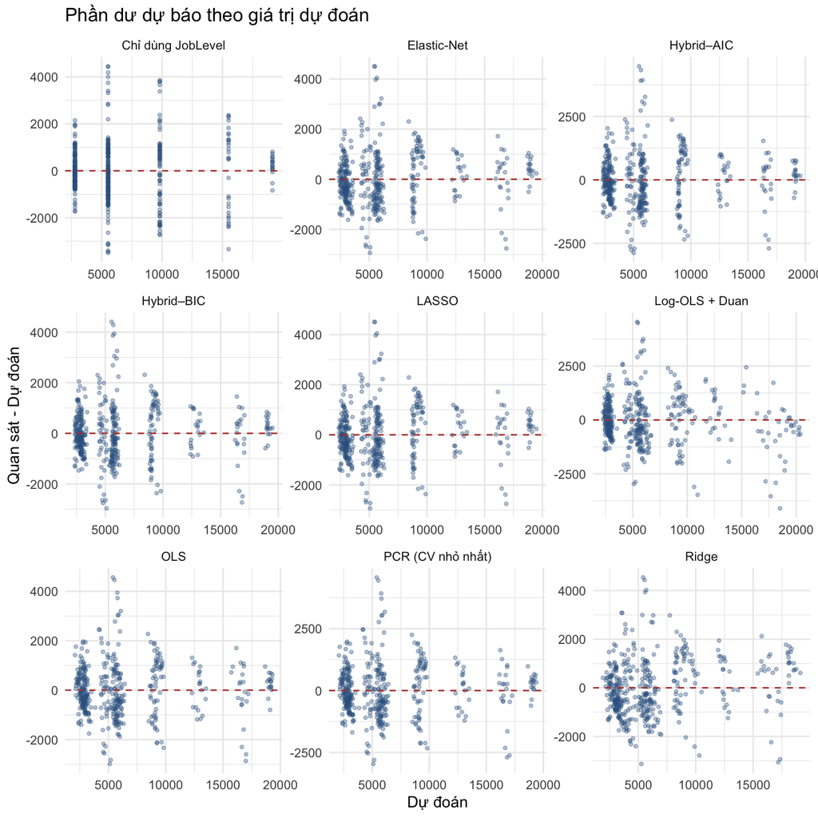

```r
print(p_residual)
```

```r
final_test_prediction <- as.numeric(predictions_primary[[reference_model]])
test_error_data <- test_data %>%
  mutate(
    Prediction = final_test_prediction,
    Error = MonthlyIncome - Prediction,
    AbsoluteError = abs(Error)
  )

subgroup_error <- bind_rows(
  test_error_data %>%
    group_by(Nhom = "Gender", Muc = as.character(Gender)) %>%
    summarise(N = n(), Bias = mean(Error), MAE = mean(AbsoluteError), .groups = "drop"),
  test_error_data %>%
    group_by(Nhom = "Department", Muc = as.character(Department)) %>%
    summarise(N = n(), Bias = mean(Error), MAE = mean(AbsoluteError), .groups = "drop"),
  test_error_data %>%
    group_by(Nhom = "JobLevel", Muc = as.character(JobLevel)) %>%
    summarise(N = n(), Bias = mean(Error), MAE = mean(AbsoluteError), .groups = "drop")
)

knitr::kable(
  subgroup_error,
  digits = 1,
  caption = paste0("Sai số theo nhóm của mô hình cuối cùng ", reference_model)
)
```

Sai số theo nhóm của mô hình cuối cùng Hybrid–BIC

| Nhom | Muc | N | Bias | MAE |
| --- | --- | --- | --- | --- |
| Gender | Female | 178 | -27.4 | 782.0 |
| Gender | Male | 261 | 33.3 | 793.5 |
| Department | Human Resources | 23 | 37.8 | 789.9 |
| Department | Research & Development | 291 | 32.1 | 763.2 |
| Department | Sales | 125 | -51.1 | 848.4 |
| JobLevel | 1 | 161 | -26.1 | 543.6 |
| JobLevel | 2 | 159 | -32.5 | 996.9 |
| JobLevel | 3 | 72 | 167.7 | 1007.0 |
| JobLevel | 4 | 30 | -105.5 | 707.6 |
| JobLevel | 5 | 17 | 251.3 | 385.1 |

Sai số nhóm chỉ là chẩn đoán dự báo. Nó không phải một kiểm định đầy đủ về công bằng lương, đặc biệt khi các nhóm có kích thước và cơ cấu nghề nghiệp khác nhau.

## 3.8. Kết quả lựa chọn biến của LASSO

### 3.8.1. Hệ số LASSO khác 0

```r
original_predictors <- setdiff(names(train_data), "MonthlyIncome")
design_sd <- apply(x_train, 2, sd)

extract_active_lasso <- function(rule) {
  coef_matrix <- as.matrix(coef(cv_lasso, s = rule))
  active_names <- rownames(coef_matrix)[coef_matrix[, 1] != 0]
  active_names <- setdiff(active_names, "(Intercept)")
  tibble(
    `Quy tắc` = rule,
    `Cột thiết kế` = active_names,
    `Biến gốc` = vapply(
      active_names, parent_feature,
      original_names = original_predictors,
      FUN.VALUE = character(1)
    ),
    `Hệ số thang gốc` = coef_matrix[active_names, 1],
    `Hệ số × SD(X)` = coef_matrix[active_names, 1] * design_sd[active_names]
  ) %>%
    arrange(desc(abs(`Hệ số × SD(X)`)))
}

lasso_active_table <- bind_rows(
  extract_active_lasso("lambda.min"),
  extract_active_lasso("lambda.1se")
)

knitr::kable(
  lasso_active_table,
  digits = 3,
  caption = "Các cột thiết kế được LASSO giữ lại"
)
```

Các cột thiết kế được LASSO giữ lại

| Quy tắc | Cột thiết kế | Biến gốc | Hệ số thang gốc | Hệ số × SD(X) |
| --- | --- | --- | --- | --- |
| lambda.min | JobLevel.5 | JobLevel | 10402.667 | 2277.665 |
| lambda.min | JobLevel.4 | JobLevel | 7955.641 | 2079.868 |
| lambda.min | JobLevel.3 | JobLevel | 4506.444 | 1571.933 |
| lambda.min | JobRole.Manager | JobRole | 3462.167 | 894.071 |
| lambda.min | JobRole.Research Director | JobRole | 3486.866 | 810.301 |
| lambda.min | JobLevel.2 | JobLevel | 1416.067 | 681.559 |
| lambda.min | JobRole.Laboratory Technician | JobRole | -1298.373 | -496.335 |
| lambda.min | JobRole.Research Scientist | JobRole | -1125.380 | -451.024 |
| lambda.min | TotalWorkingYears | TotalWorkingYears | 46.473 | 365.876 |
| lambda.min | JobRole.Sales Representative | JobRole | -1393.773 | -313.365 |
| lambda.min | JobRole.Human Resources | JobRole | -693.791 | -120.376 |
| lambda.min | NumCompaniesWorked | NumCompaniesWorked | 20.177 | 50.788 |
| lambda.min | JobInvolvement.3 | JobInvolvement | -61.412 | -30.189 |
| lambda.min | EducationField.Marketing | EducationField | 96.299 | 29.980 |
| lambda.min | Education.4 | Education | 63.748 | 28.431 |
| lambda.min | RelationshipSatisfaction.2 | RelationshipSatisfaction | 48.834 | 19.246 |
| lambda.min | YearsSinceLastPromotion | YearsSinceLastPromotion | 5.246 | 16.971 |
| lambda.min | JobInvolvement.2 | JobInvolvement | 30.382 | 13.283 |
| lambda.min | YearsInCurrentRole | YearsInCurrentRole | 2.640 | 9.799 |
| lambda.min | MaritalStatus.Married | MaritalStatus | 16.275 | 8.099 |
| lambda.min | Education.2 | Education | -19.823 | -7.705 |
| lambda.min | EnvironmentSatisfaction.3 | EnvironmentSatisfaction | -11.887 | -5.511 |
| lambda.min | Gender.Male | Gender | 10.569 | 5.175 |
| lambda.min | EducationField.Other | EducationField | -18.596 | -4.356 |
| lambda.min | MaritalStatus.Single | MaritalStatus | -3.188 | -1.509 |
| lambda.1se | JobLevel.5 | JobLevel | 9508.150 | 2081.810 |
| lambda.1se | JobLevel.4 | JobLevel | 7136.054 | 1865.601 |
| lambda.1se | JobLevel.3 | JobLevel | 3945.516 | 1376.271 |
| lambda.1se | JobRole.Manager | JobRole | 3459.974 | 893.505 |
| lambda.1se | JobRole.Research Director | JobRole | 3463.859 | 804.955 |
| lambda.1se | TotalWorkingYears | TotalWorkingYears | 69.657 | 548.401 |
| lambda.1se | JobRole.Laboratory Technician | JobRole | -1399.573 | -535.021 |
| lambda.1se | JobRole.Research Scientist | JobRole | -1242.383 | -497.916 |
| lambda.1se | JobLevel.2 | JobLevel | 1032.462 | 496.928 |
| lambda.1se | JobRole.Sales Representative | JobRole | -1362.793 | -306.400 |
| lambda.1se | JobRole.Human Resources | JobRole | -537.310 | -93.226 |

`glmnet` chọn từng cột biến giả (dummy), không nhất thiết chọn hoặc loại toàn bộ một biến phân loại. Hệ số thang gốc không thể so sánh trực tiếp giữa biến liên tục và biến giả; cột `Hệ số × SD(X)` giúp so sánh quy mô dễ hơn, nhưng vẫn chỉ phản ánh mối liên hệ dự báo.

### 3.8.2. Kiểm tra độ ổn định bằng lấy mẫu lặp trên tập Train

```r
set.seed(SEED + 20L)
selection_counts <- setNames(integer(ncol(x_train)), colnames(x_train))

for (b in seq_len(B_STABILITY)) {
  bootstrap_train_id <- sample.int(nrow(x_train), replace = TRUE)
  x_boot <- x_train[bootstrap_train_id, , drop = FALSE]
  y_boot <- y_train[bootstrap_train_id]

  set.seed(SEED + 100L + b)
  cv_boot <- glmnet::cv.glmnet(
    x_boot, y_boot,
    alpha = 1, nfolds = 5,
    standardize = TRUE
  )
  coef_boot <- as.matrix(coef(cv_boot, s = "lambda.min"))[-1, 1]
  selection_counts <- selection_counts + as.integer(coef_boot != 0)
}

selection_stability <- tibble(
  `Cột thiết kế` = names(selection_counts),
  `Biến gốc` = vapply(
    names(selection_counts), parent_feature,
    original_names = original_predictors,
    FUN.VALUE = character(1)
  ),
  `Tần suất chọn` = selection_counts / B_STABILITY,
  `Mức ổn định` = case_when(
    `Tần suất chọn` >= 0.70 ~ "Ổn định (>=70%)",
    `Tần suất chọn` >= 0.40 ~ "Phụ thuộc mẫu (40–70%)",
    TRUE ~ "Không ổn định (<40%)"
  )
) %>%
  arrange(desc(`Tần suất chọn`), `Cột thiết kế`)

knitr::kable(
  selection_stability,
  digits = 2,
  caption = paste0(
    "Độ ổn định LASSO lambda.min qua ", B_STABILITY,
    " lần lấy mẫu lại từ Train"
  )
)
```

Độ ổn định LASSO lambda.min qua 100 lần lấy mẫu lại từ Train

| Cột thiết kế | Biến gốc | Tần suất chọn | Mức ổn định |
| --- | --- | --- | --- |
| JobLevel.2 | JobLevel | 1.00 | Ổn định (>=70%) |
| JobLevel.3 | JobLevel | 1.00 | Ổn định (>=70%) |
| JobLevel.4 | JobLevel | 1.00 | Ổn định (>=70%) |
| JobLevel.5 | JobLevel | 1.00 | Ổn định (>=70%) |
| JobRole.Human Resources | JobRole | 1.00 | Ổn định (>=70%) |
| JobRole.Laboratory Technician | JobRole | 1.00 | Ổn định (>=70%) |
| JobRole.Manager | JobRole | 1.00 | Ổn định (>=70%) |
| JobRole.Research Director | JobRole | 1.00 | Ổn định (>=70%) |
| JobRole.Research Scientist | JobRole | 1.00 | Ổn định (>=70%) |
| JobRole.Sales Representative | JobRole | 1.00 | Ổn định (>=70%) |
| TotalWorkingYears | TotalWorkingYears | 1.00 | Ổn định (>=70%) |
| NumCompaniesWorked | NumCompaniesWorked | 0.97 | Ổn định (>=70%) |
| RelationshipSatisfaction.2 | RelationshipSatisfaction | 0.88 | Ổn định (>=70%) |
| Education.4 | Education | 0.86 | Ổn định (>=70%) |
| JobInvolvement.3 | JobInvolvement | 0.82 | Ổn định (>=70%) |
| EducationField.Marketing | EducationField | 0.81 | Ổn định (>=70%) |
| Gender.Male | Gender | 0.77 | Ổn định (>=70%) |
| EducationField.Other | EducationField | 0.74 | Ổn định (>=70%) |
| MaritalStatus.Married | MaritalStatus | 0.72 | Ổn định (>=70%) |
| BusinessTravel.Travel_Frequently | BusinessTravel | 0.69 | Phụ thuộc mẫu (40–70%) |
| YearsInCurrentRole | YearsInCurrentRole | 0.68 | Phụ thuộc mẫu (40–70%) |
| BusinessTravel.Travel_Rarely | BusinessTravel | 0.67 | Phụ thuộc mẫu (40–70%) |
| Education.5 | Education | 0.66 | Phụ thuộc mẫu (40–70%) |
| YearsSinceLastPromotion | YearsSinceLastPromotion | 0.66 | Phụ thuộc mẫu (40–70%) |
| JobSatisfaction.3 | JobSatisfaction | 0.65 | Phụ thuộc mẫu (40–70%) |
| RelationshipSatisfaction.3 | RelationshipSatisfaction | 0.65 | Phụ thuộc mẫu (40–70%) |
| JobInvolvement.2 | JobInvolvement | 0.63 | Phụ thuộc mẫu (40–70%) |
| JobRole.Healthcare Representative | JobRole | 0.63 | Phụ thuộc mẫu (40–70%) |
| PerformanceRating.4 | PerformanceRating | 0.61 | Phụ thuộc mẫu (40–70%) |
| TrainingTimesLastYear | TrainingTimesLastYear | 0.60 | Phụ thuộc mẫu (40–70%) |
| Education.2 | Education | 0.59 | Phụ thuộc mẫu (40–70%) |
| EnvironmentSatisfaction.3 | EnvironmentSatisfaction | 0.59 | Phụ thuộc mẫu (40–70%) |
| OverTime.Yes | OverTime | 0.59 | Phụ thuộc mẫu (40–70%) |
| WorkLifeBalance.4 | WorkLifeBalance | 0.59 | Phụ thuộc mẫu (40–70%) |
| MaritalStatus.Single | MaritalStatus | 0.58 | Phụ thuộc mẫu (40–70%) |
| EnvironmentSatisfaction.4 | EnvironmentSatisfaction | 0.56 | Phụ thuộc mẫu (40–70%) |
| RelationshipSatisfaction.4 | RelationshipSatisfaction | 0.55 | Phụ thuộc mẫu (40–70%) |
| WorkLifeBalance.3 | WorkLifeBalance | 0.55 | Phụ thuộc mẫu (40–70%) |
| Education.1 | Education | 0.54 | Phụ thuộc mẫu (40–70%) |
| JobSatisfaction.2 | JobSatisfaction | 0.53 | Phụ thuộc mẫu (40–70%) |
| DistanceFromHome | DistanceFromHome | 0.51 | Phụ thuộc mẫu (40–70%) |
| JobSatisfaction.4 | JobSatisfaction | 0.51 | Phụ thuộc mẫu (40–70%) |
| Department.Sales | Department | 0.50 | Phụ thuộc mẫu (40–70%) |
| EducationField.Life Sciences | EducationField | 0.50 | Phụ thuộc mẫu (40–70%) |
| EnvironmentSatisfaction.2 | EnvironmentSatisfaction | 0.50 | Phụ thuộc mẫu (40–70%) |
| EducationField.Technical Degree | EducationField | 0.47 | Phụ thuộc mẫu (40–70%) |
| WorkLifeBalance.2 | WorkLifeBalance | 0.46 | Phụ thuộc mẫu (40–70%) |
| JobInvolvement.4 | JobInvolvement | 0.45 | Phụ thuộc mẫu (40–70%) |
| JobRole.Manufacturing Director | JobRole | 0.43 | Phụ thuộc mẫu (40–70%) |
| YearsWithCurrManager | YearsWithCurrManager | 0.41 | Phụ thuộc mẫu (40–70%) |
| Age | Age | 0.40 | Phụ thuộc mẫu (40–70%) |
| EducationField.Medical | EducationField | 0.33 | Không ổn định (<40%) |
| YearsAtCompany | YearsAtCompany | 0.31 | Không ổn định (<40%) |
| Department.Research & Development | Department | 0.10 | Không ổn định (<40%) |

Tần suất này dùng cùng quy tắc `lambda.min` với LASSO trong bảng Test. Nó cho biết một biến được giữ lại bao nhiêu lần khi lấy mẫu Train. Đây là kiểm tra độ ổn định, không phải xác suất một biến “thực sự có tác động”. Những biến có tần suất thấp không nên được dùng để đưa ra khuyến nghị quản trị mạnh.

## 3.9. Mô hình cuối cùng dùng để dự báo

**Mô hình cuối cùng được chọn là Hybrid–BIC**, với công thức:

$$\mathrm{MonthlyIncome} \sim \mathrm{JobLevel}+\mathrm{JobRole}
+\mathrm{TotalWorkingYears}.$$

Nested CV sử dụng riêng Train đã chọn Hybrid–BIC. Mô hình nằm trong ngưỡng một SE và có độ phức tạp thấp nhất trong nhóm cạnh tranh. Kết quả Test chỉ xác nhận khả năng khái quát hóa của lựa chọn này.

Hybrid–AIC có hiệu suất gần tương đương và khoảng tin cậy của chênh lệch RMSE chứa 0. Vì vậy, chưa có bằng chứng Hybrid–AIC kém hơn rõ ràng. Hybrid–BIC vẫn được ưu tiên vì dùng ít hơn một biến và dễ triển khai hơn.

Ridge, LASSO và Elastic-Net **không được chọn làm mô hình cuối cùng**. So với Hybrid–BIC, khoảng tin cậy 95% của chênh lệch RMSE lần lượt là [89,4; 163,1], [0,3; 23,0] và [0,5; 23,8]. Cả ba khoảng đều nằm trên 0 trong lần chia dữ liệu này. Ridge kém hơn rõ rệt; LASSO và Elastic-Net chỉ kém hơn một khoảng nhỏ.

```r
expected_final_terms <- c("JobLevel", "JobRole", "TotalWorkingYears")
stopifnot(final_procedure_name %in% names(step_models))
selected_train_model <- step_models[[final_procedure_name]]
selected_bic_terms <- attr(terms(selected_train_model), "term.labels")
stopifnot(setequal(selected_bic_terms, expected_final_terms))

final_formula <- formula(selected_train_model)
final_model <- lm(final_formula, data = df_model)
final_vcov_hc3 <- sandwich::vcovHC(final_model, type = "HC3")
final_hc3 <- lmtest::coeftest(final_model, vcov. = final_vcov_hc3)
final_global_hc3 <- car::linearHypothesis(
  final_model,
  names(coef(final_model))[-1],
  vcov. = final_vcov_hc3,
  test = "F"
)
final_critical_t <- qt(0.975, df.residual(final_model))

final_bp <- lmtest::bptest(final_model)
final_reset <- lmtest::resettest(
  final_model, power = 2:3, type = "fitted"
)
final_shapiro <- shapiro.test(residuals(final_model))

final_design <- model.matrix(final_model)[, -1, drop = FALSE]
final_vif <- vapply(seq_len(ncol(final_design)), function(j) {
  auxiliary_fit <- lm(
    final_design[, j] ~ final_design[, -j, drop = FALSE]
  )
  1 / (1 - summary(auxiliary_fit)$r.squared)
}, FUN.VALUE = numeric(1))

final_test_metrics <- metrics_primary %>%
  filter(`Mô hình` == final_procedure_name) %>%
  select(RMSE, MAE, R2)

final_oof_residuals <- nested_predictions %>%
  filter(Model == final_procedure_name) %>%
  mutate(Residual = Actual - Prediction)
screening_cutoff <- unname(quantile(
  final_oof_residuals$Residual,
  probs = 0.05
))

final_model_summary <- tibble(
  `Nội dung` = c(
    "Mô hình cuối cùng",
    "Công thức",
    "Cách chọn công thức",
    "Dữ liệu fit mô hình triển khai",
    "RMSE Test trước khi fit lại",
    "MAE Test trước khi fit lại",
    "R-squared Test trước khi fit lại",
    "Ngưỡng phần dư ngoài-fold 5%"
  ),
  `Kết quả` = c(
    final_procedure_name,
    paste(deparse(final_formula), collapse = " "),
    "Nested CV một-SE; Hybrid Stepwise–BIC trên Train",
    paste0("Toàn bộ ", nrow(df_model), " quan sát"),
    round(final_test_metrics$RMSE, 3),
    round(final_test_metrics$MAE, 3),
    round(final_test_metrics$R2, 4),
    round(screening_cutoff, 3)
  )
)

final_coefficient_table <- tibble(
  `Hệ số` = rownames(final_hc3),
  `Ước lượng` = final_hc3[, 1],
  `SE HC3` = final_hc3[, 2],
  `p-value HC3` = final_hc3[, 4],
  `CI 2.5%` = final_hc3[, 1] - final_critical_t * final_hc3[, 2],
  `CI 97.5%` = final_hc3[, 1] + final_critical_t * final_hc3[, 2]
)

final_diagnostic_table <- tibble(
  `Chỉ tiêu` = c(
    "RESET: dạng hàm",
    "Breusch–Pagan: phương sai đồng nhất",
    "Shapiro–Wilk: phần dư chuẩn",
    "VIF lớn nhất",
    "Wald HC3 tổng thể"
  ),
  `Kết quả` = c(
    format_p(final_reset$p.value),
    format_p(final_bp$p.value),
    format_p(final_shapiro$p.value),
    sprintf("%.3f", max(final_vif)),
    format_p(final_global_hc3$`Pr(>F)`[2])
  ),
  `Kết luận` = c(
    if (final_reset$p.value < 0.05) "Vi phạm" else "Chưa phát hiện vi phạm",
    if (final_bp$p.value < 0.05) "Vi phạm" else "Chưa phát hiện vi phạm",
    if (final_shapiro$p.value < 0.05) "Vi phạm" else "Chưa phát hiện vi phạm",
    if (max(final_vif) < 5) "Đạt" else "Cần xem xét",
    "Mô hình có ý nghĩa tổng thể"
  )
)

knitr::kable(
  final_model_summary,
  caption = "Mô hình cuối cùng dùng để dự báo thu nhập"
)
```

Mô hình cuối cùng dùng để dự báo thu nhập

| Nội dung | Kết quả |
| --- | --- |
| Mô hình cuối cùng | Hybrid–BIC |
| Công thức | MonthlyIncome ~ JobLevel + JobRole + TotalWorkingYears |
| Cách chọn công thức | Nested CV một-SE; Hybrid Stepwise–BIC trên Train |
| Dữ liệu fit mô hình triển khai | Toàn bộ 1470 quan sát |
| RMSE Test trước khi fit lại | 1042.196 |
| MAE Test trước khi fit lại | 788.864 |
| R-squared Test trước khi fit lại | 0.9478 |
| Ngưỡng phần dư ngoài-fold 5% | -1587.23 |

```r
knitr::kable(
  final_coefficient_table,
  digits = 3,
  caption = "Hệ số OLS cuối cùng với suy luận HC3"
)
```

Hệ số OLS cuối cùng với suy luận HC3

| Hệ số | Ước lượng | SE HC3 | p-value HC3 | CI 2.5% | CI 97.5% |
| --- | --- | --- | --- | --- | --- |
| (Intercept) | 3782.940 | 142.275 | 0.000 | 3503.855 | 4062.026 |
| JobLevel2 | 1616.232 | 117.587 | 0.000 | 1385.575 | 1846.889 |
| JobLevel3 | 4877.149 | 169.672 | 0.000 | 4544.320 | 5209.977 |
| JobLevel4 | 8405.495 | 214.435 | 0.000 | 7984.862 | 8826.129 |
| JobLevel5 | 11005.252 | 237.161 | 0.000 | 10540.038 | 11470.467 |
| JobRoleHealthcare Representative | 6.058 | 131.393 | 0.963 | -251.681 | 263.797 |
| JobRoleHuman Resources | -840.383 | 184.960 | 0.000 | -1203.201 | -477.566 |
| JobRoleLaboratory Technician | -1257.471 | 147.402 | 0.000 | -1546.613 | -968.329 |
| JobRoleManager | 3332.013 | 145.946 | 0.000 | 3045.725 | 3618.300 |
| JobRoleManufacturing Director | -94.878 | 125.797 | 0.451 | -341.640 | 151.884 |
| JobRoleResearch Director | 3380.517 | 149.905 | 0.000 | 3086.464 | 3674.571 |
| JobRoleResearch Scientist | -1183.292 | 138.268 | 0.000 | -1454.518 | -912.066 |
| JobRoleSales Representative | -1479.930 | 166.142 | 0.000 | -1805.834 | -1154.027 |
| TotalWorkingYears | 39.934 | 6.336 | 0.000 | 27.505 | 52.364 |

```r
knitr::kable(
  final_diagnostic_table,
  caption = "Chẩn đoán đúng mô hình OLS ba biến cuối cùng"
)
```

Chẩn đoán đúng mô hình OLS ba biến cuối cùng

| Chỉ tiêu | Kết quả | Kết luận |
| --- | --- | --- |
| RESET: dạng hàm | 0.152 | Chưa phát hiện vi phạm |
| Breusch–Pagan: phương sai đồng nhất | <1e-16 | Vi phạm |
| Shapiro–Wilk: phần dư chuẩn | 5.7e-16 | Vi phạm |
| VIF lớn nhất | 4.566 | Đạt |
| Wald HC3 tổng thể | <1e-16 | Mô hình có ý nghĩa tổng thể |

Mô hình cuối không vi phạm dạng hàm theo RESET và không có đa cộng tuyến đáng kể. Tuy nhiên, Breusch–Pagan và Shapiro–Wilk vẫn bác bỏ phương sai đồng nhất và phần dư chuẩn. Vì vậy, báo cáo dùng HC3 khi suy luận. Hai vi phạm này không làm mất giá trị dự báo điểm đã đánh giá trên Test.

Mô hình fit lại dùng toàn bộ dữ liệu để ước lượng hệ số cuối cùng. Các chỉ số Test trong bảng thuộc phiên bản chỉ fit trên Train, nên vẫn là kết quả đánh giá trước khi fit lại. Không dùng dữ liệu đã fit lại để tính lại hiệu suất Test.

Với nhân viên mới, cần cung cấp đúng ba biến và giữ nguyên các mức phân loại. Dự báo được tạo bằng `predict(final_model, newdata = new_employee)`. Kết quả chỉ là mức lương tham chiếu, không phải quyết định lương tự động.

Ngưỡng sàng lọc lấy phân vị 5% của phần dư ngoài-fold trong Train. Nhân viên được gắn cờ khi thu nhập thực tế trừ dự báo thấp hơn ngưỡng. Ngưỡng kiểm soát tỷ lệ cảnh báo tham chiếu tốt hơn một MAE tùy ý.

Tập Test không chọn mô hình nhưng vẫn chỉ là một mẫu đánh giá. Cần dữ liệu độc lập mới trước khi triển khai thực tế.

# 4. Kết luận và đề xuất hành động

## 4.1. Nhận xét tổng hợp

```r
stable_design_columns <- selection_stability %>%
  filter(`Tần suất chọn` >= 0.70) %>%
  nrow()

summary_table <- tibble(
  `Nội dung` = c(
    "Mô hình cuối cùng dùng để dự báo",
    "Công thức mô hình cuối cùng",
    "Nested-CV RMSE trung bình",
    "Nested-CV SE của RMSE",
    "RMSE Test", "MAE Test", "Test R-squared",
    "Ngưỡng phần dư ngoài-fold 5%",
    "Biến được chọn bởi Hybrid–AIC",
    "Biến được chọn bởi Hybrid–BIC",
    "Số cột LASSO ổn định qua lấy mẫu lặp"
  ),
  `Kết quả` = c(
    final_procedure_name,
    paste(deparse(final_formula), collapse = " "),
    round(selected_nested_row$`RMSE trung bình`, 2),
    round(selected_nested_row$`SE của RMSE`, 2),
    round(final_test_metrics$RMSE, 2),
    round(final_test_metrics$MAE, 2),
    round(final_test_metrics$R2, 4),
    round(screening_cutoff, 2),
    paste(attr(terms(step_hybrid_aic), "term.labels"), collapse = ", "),
    paste(attr(terms(step_hybrid_bic), "term.labels"), collapse = ", "),
    stable_design_columns
  )
)
knitr::kable(summary_table, caption = "Tóm tắt kết quả có thể tái lập")
```

Tóm tắt kết quả có thể tái lập

| Nội dung | Kết quả |
| --- | --- |
| Mô hình cuối cùng dùng để dự báo | Hybrid–BIC |
| Công thức mô hình cuối cùng | MonthlyIncome ~ JobLevel + JobRole + TotalWorkingYears |
| Nested-CV RMSE trung bình | 1067.15 |
| Nested-CV SE của RMSE | 21.51 |
| RMSE Test | 1042.2 |
| MAE Test | 788.86 |
| Test R-squared | 0.9478 |
| Ngưỡng phần dư ngoài-fold 5% | -1587.23 |
| Biến được chọn bởi Hybrid–AIC | JobLevel, JobRole, TotalWorkingYears, NumCompaniesWorked |
| Biến được chọn bởi Hybrid–BIC | JobLevel, JobRole, TotalWorkingYears |
| Số cột LASSO ổn định qua lấy mẫu lặp | 19 |

Các kết luận cuối cùng được giới hạn như sau:

1. `JobLevel`, `JobRole` và kinh nghiệm cung cấp phần lớn tín hiệu liên hệ và dự báo thu nhập trong bộ dữ liệu mô phỏng này. Điều đó không chứng minh thay đổi một biến sẽ gây ra thay đổi lương tương ứng.
2. OLS ba biến cuối cùng không vi phạm dạng hàm và chưa có đa cộng tuyến nghiêm trọng. Phương sai thay đổi và phần dư không chuẩn vẫn tồn tại, nên phần suy luận hệ số dùng HC3.
3. Forward, Backward và Hybrid dùng AIC/BIC trên tập Train. Trong dữ liệu này, ba hướng tìm kiếm hội tụ về cùng mô hình cho từng tiêu chí; BIC chọn mô hình gọn hơn AIC.
4. Nested CV chỉ dùng Train để chọn Hybrid–BIC. Bootstrap ghép cặp chỉ đo độ bất định trên Test cố định, không đo lại biến động huấn luyện.
5. Ridge, LASSO và Elastic-Net đều có sai số Test cao hơn Hybrid–BIC. Ridge kém hơn rõ rệt, còn LASSO và Elastic-Net chỉ kém hơn một khoảng nhỏ. Vì vậy, ba mô hình phạt không được chọn làm mô hình cuối cùng.
6. LASSO lựa chọn biến theo sai số kiểm định chéo và hệ số khác 0, không theo p-value. Chỉ những cột có tần suất lựa chọn cao khi lấy mẫu lại mới được mô tả là ổn định.
7. Vì dữ liệu là mô phỏng và không có bộ dữ liệu độc lập khác, kết quả phù hợp cho minh họa phương pháp thống kê; chưa đủ để triển khai chính sách lương thực tế.

## 4.2. Đề xuất hành động cho bộ phận nhân sự

Kết quả phân tích không nên dừng lại ở việc chọn mô hình có RMSE thấp nhất. Giá trị thực tế của mô hình nằm ở khả năng hỗ trợ HR phát hiện các trường hợp cần xem xét và chuẩn hóa quy trình trả lương. Các hành động được đề xuất theo thứ tự ưu tiên như sau:

### Hành động 1: Chuẩn hóa khung lương theo cấp bậc và vị trí

- Xây dựng bảng lương tham chiếu theo tổ hợp `JobLevel x JobRole`, vì đây là hai nhóm biến được giữ lại nhất quán bởi OLS, Stepwise và LASSO.
- So sánh trung vị và khoảng biến động thu nhập trong cùng cấp bậc, cùng vị trí thay vì so sánh trực tiếp toàn công ty.
- Kiểm tra lại những vị trí có mức lương chồng lấn lớn giữa các cấp để xác định nguyên nhân đến từ chuyên môn, trách nhiệm hay dữ liệu chưa đầy đủ.

### Hành động 2: Dùng Hybrid–BIC làm công cụ sàng lọc ban đầu

- Nested CV chọn Hybrid–BIC theo quy tắc một-SE và tính gọn trên Train. Test xác nhận mô hình khái quát hóa tốt trên dữ liệu giữ lại.
- Tính chênh lệch bằng thu nhập thực tế trừ thu nhập dự đoán của mô hình.
- Ưu tiên trường hợp có phần dư thấp hơn phân vị 5% ngoài-fold của Train. Đây là ngưỡng rà soát, không phải căn cứ tự động tăng lương.
- HR cần xem thêm thành tích, lịch sử lương, trách nhiệm và dữ liệu thị trường trước khi đưa ra quyết định.

### Hành động 3: Kiểm tra tính nhất quán giữa các nhóm nhân viên

- Theo dõi sai lệch dự báo trung bình và MAE theo các biến `Gender`, `Department` và `JobLevel`.
- Nếu một nhóm liên tục có sai lệch âm, HR cần kiểm tra xem nhóm đó có đang nhận mức lương thấp hơn khung tham chiếu hay mô hình đang thiếu biến giải thích quan trọng.
- Không dùng việc hệ số `Gender` không có ý nghĩa thống kê để khẳng định đã đạt công bằng lương. Đánh giá công bằng cần xem thêm cơ cấu chức vụ, cấp bậc, kinh nghiệm và khoảng tin cậy của chênh lệch.
- Mô hình học từ lương lịch sử nên có thể tái tạo bất bình đẳng sẵn có. HR phải kiểm tra sai lệch nhóm trước mọi ứng dụng thực tế.

### Hành động 4: Hoàn thiện dữ liệu trước khi áp dụng thực tế

- Bổ sung các biến có ý nghĩa đối với thị trường lao động như địa điểm làm việc, kỹ năng chuyên môn, chứng chỉ, quy mô nhóm quản lý, mức lương thị trường và kết quả đánh giá qua nhiều năm.
- Chuẩn hóa đơn vị tiền tệ, thời điểm ghi nhận và định nghĩa các biến trước khi huấn luyện lại mô hình.
- Kiểm tra dữ liệu khuyết, dữ liệu trùng lặp và ngoại lai bằng cùng quy trình đã trình bày trong báo cáo.

### Hành động 5: Thử nghiệm có kiểm soát và theo dõi định kỳ

- Chạy thử mô hình trên dữ liệu lương thực tế nhưng chưa sử dụng kết quả để thay đổi lương ngay lập tức.
- HR và nhóm phân tích cùng xem xét các trường hợp bị gắn cờ để đánh giá tỷ lệ cảnh báo hữu ích và nguyên nhân của cảnh báo sai.
- Theo dõi RMSE, MAE, sai lệch theo nhóm và tỷ lệ trường hợp được HR xác nhận sau mỗi kỳ rà soát.
- Đánh giá lại mô hình theo quý hoặc khi cơ cấu chức danh, khung lương hay thị trường lao động thay đổi đáng kể.

## 4.3. Thông điệp hành động chính

**Không sử dụng mô hình để tự động quyết định mức lương.** Hãy dùng mô hình mà chúng ta chọn như một công cụ tạo mức lương tham chiếu, ưu tiên rà soát các nhân viên có thu nhập thấp hơn đáng kể so với dự đoán, sau đó để HR đưa ra quyết định cuối cùng dựa trên thông tin nghiệp vụ đầy đủ. Đây là bước hành động trực tiếp nhất có thể rút ra từ kết quả của báo cáo.

# Phụ lục tái lập

```r
seed_table <- tibble(
  `Công đoạn` = c(
    "Chia Train/Test",
    "Fold CV toàn Train",
    "Nested outer folds",
    "Nested inner folds",
    "Bootstrap Test",
    "Ổn định LASSO"
  ),
  `Seed` = c(
    SEED,
    SEED + 1L,
    SEED + 30L,
    SEED + 1001L,
    SEED + 10L,
    SEED + 20L
  )
)
knitr::kable(seed_table, caption = "Các seed chính của báo cáo")
```

Các seed chính của báo cáo

| Công đoạn | Seed |
| --- | --- |
| Chia Train/Test | 123 |
| Fold CV toàn Train | 124 |
| Nested outer folds | 153 |
| Nested inner folds | 1124 |
| Bootstrap Test | 133 |
| Ổn định LASSO | 143 |